# PROBLEM STATEMENT•

## DOMAIN: Industrial safety. NLP based Chatbot.

## •CONTEXT:

The database comes fromone of the biggest industry in Brazil and in the world. It is an urgent need for industries/companies around the globe to understand why employees still suffer some injuries/accidents in plants. Sometimes they also die in such environment.

## •DATA DESCRIPTION:

This The database is basically records of accidents from12 different plants in 03 different countrieswhich every line in the data is an occurrence of an accident.Columns description:

‣Data: timestamp or time/date information‣Countries: which country the accident occurred (anonymised)

‣Local: the city where the manufacturing plant is located (anonymised)

‣Industry sector: which sector the plant belongs to

‣Accident level: from I to VI, it registers how severe was the accident (I means not severe but VI means very severe)

‣Potential Accident Level: Depending on the Accident Level, the database also registers how severe the accident could have been (due to other factors involved in the accident)

‣Genre: if the person is male of female

‣Employee or Third Party: if the injured person is an employee or a third party‣

Critical Risk: some description of the risk involved in the accident

‣Description: Detailed description of how the accident happened.Link to download the dataset:

# •PROJECT OBJECTIVE:

Design a ML/DL based chatbot utility which can help the professionals to highlight the safety risk as per the incident description.

•PROJECT TASK: 1.Milestone 1:[ Score: 40 points ]‣

Input: Context and Dataset‣Process:

‣Step 1: Import the data [ 3 points ]

‣Step 2: Data cleansing [ 5 points ]

‣Step 3: Data preprocessing (NLP Preprocessing techniques) [ 7 points ]

‣Step 4: Data preparation - Cleansed data in .xlsx or .csv file [ 5 points ]

‣Step 5: Design train and test basic machine learning classifiers [ 10 Points ]

‣Step 6: Interim report [ 10 points ]

‣Submission: Interim report, Jupyter Notebook with all the steps in Milestone-12.

2.Milestone 2: [ Score: 60 points ]‣Input: Preprocessed output from Milestone-

1‣Process:

‣Step 1: Design, train and test Neural networks classifiers [ 5 points ]‣

Step 2: Design, train and test RNN or LSTM classifiers [ 10 points ]‣

Step 3: Choose the best performing classifier and pickle it. [ 5 points ]‣

Step 4: Final Report [40 Points]‣Submission: Final report, Jupyter Notebook with all the steps in Milestone-1 and Milestone-23.Milestone 3: [ Optional ]‣Process:‣Step 1: Design a clickable UI based chatbot interface ‣Submission: Final report, Jupyter Notebook with the addition of clickable UI based interface‣Hints: ‣Please refer to the blog to understand the basic designing and functioning of chatbots -->

## Import the necessary libraries

```python
import pandas as pd
import matplotlib.pyplot as plt
%matplotlib inline
import seaborn as sns
import random, re
import time
# used to supress display of warnings
import warnings
import string
import missingno as mino
import tensorflow as tf
# nlp libraries
import nltk
nltk.download('punkt')
nltk.download('stopwords')
nltk.download('wordnet')
nltk.download('averaged_perceptron_tagger')
from nltk.stem import WordNetLemmatizer
from nltk.corpus import wordnet,stopwords
from nltk.tokenize import word_tokenize
from tqdm import tqdm
stop_words = stopwords.words('english')
from sklearn.feature_extraction.text import TfidfVectorizer
from nltk.stem import WordNetLemmatizer
from nltk.tokenize import word_tokenize
from nltk.stem import PorterStemmer

import holoviews as hv
from holoviews import opts

import os;
import pandas as pd
import numpy as np
from os import makedirs

# sampling methods
from sklearn.utils import resample
from imblearn.over_sampling import SMOTE

# import zscore for scaling the data
from scipy.stats import zscore

from scipy.stats import randint as sp_randint

# save models
import pickle

# pre-processing methods
from sklearn.model_selection import train_test_split

# the classification models
from sklearn.dummy import DummyClassifier
from sklearn.linear_model import LogisticRegression
from sklearn.linear_model import RidgeClassifier
from sklearn.linear_model import Lasso
from sklearn.neighbors import KNeighborsClassifier
from sklearn.naive_bayes import GaussianNB
from sklearn.svm import SVC
from sklearn.tree import DecisionTreeClassifier

# ensemble models
from sklearn.ensemble import RandomForestClassifier
from sklearn.ensemble import StackingClassifier
from sklearn.ensemble import BaggingClassifier
from sklearn.ensemble import ExtraTreesClassifier
from sklearn.ensemble import AdaBoostClassifier
from sklearn.ensemble import GradientBoostingClassifier
from lightgbm import LGBMClassifier
from xgboost import XGBClassifier

# methods and classes for evaluation
from sklearn.model_selection import cross_val_score
from sklearn.model_selection import StratifiedKFold

from sklearn import metrics
from sklearn.metrics import classification_report
from sklearn.metrics import accuracy_score, f1_score, confusion_matrix, recall_score, precision_score, roc_auc_score

# cross-validation methods
from sklearn.model_selection import KFold
from sklearn.model_selection import RepeatedStratifiedKFold
from sklearn.model_selection import GridSearchCV, RandomizedSearchCV

# feature selection methods
from sklearn.pipeline import Pipeline
from sklearn.decomposition import PCA
from sklearn.decomposition import TruncatedSVD
from sklearn.discriminant_analysis import LinearDiscriminantAnalysis
from sklearn.feature_selection import SelectKBest
from sklearn.feature_selection import f_classif
from sklearn.feature_selection import mutual_info_classif
from sklearn.feature_selection import RFE
from sklearn.feature_selection import RFECV

# pre-processing methods
from sklearn.preprocessing import StandardScaler
from sklearn.preprocessing import PowerTransformer
from sklearn.preprocessing import LabelEncoder

# Deep learning libraries
from keras.utils import plot_model, to_categorical
from keras.layers import Input
from keras.optimizers import SGD
from keras.models import Sequential
from keras import optimizers
from keras.models import Model
from keras.layers import Flatten, Activation, Dense, LSTM, BatchNormalization, Embedding, Dropout, Flatten, Bidirectional, GlobalMaxPool1D
from keras.models import model_from_json
from keras.regularizers import l1, l2, l1_l2
from keras.constraints import unit_norm
from keras.callbacks import ReduceLROnPlateau
from keras.callbacks import EarlyStopping
from keras.callbacks import ModelCheckpoint
from keras.models import model_from_json
from keras.models import Sequential
from keras.layers import Dense
from keras.models import load_model
# Keras pre-processing
from keras.preprocessing.text import Tokenizer
from keras.preprocessing.sequence import pad_sequences

from keras import regularizers
```

**Step 1: Import the data**

```python
from google.colab import drive
drive.mount('/content/drive/')
```

```python
project_path ='/content/drive/MyDrive/CAPSTONE_PROJECT/'
```

```python
data = pd.read_csv('/content/drive/MyDrive/CAPSTONE_PROJECT/Data Set - industrial_safety_and_health_database_with_accidents_description.csv')
```

```python
#Display top 5 data
data.head()
```

|  | Unnamed: 0 | Data | Countries | Local | Industry Sector | Accident Level | Potential Accident Level | Genre | Employee or Third Party | Critical Risk | Description |
| --- | --- | --- | --- | --- | --- | --- | --- | --- | --- | --- | --- |
| 0 | 0 | 2016-01-01 00:00:00 | Country_01 | Local_01 | Mining | I | IV | Male | Third Party | Pressed | While removing the drill rod of the Jumbo 08 f... |
| 1 | 1 | 2016-01-02 00:00:00 | Country_02 | Local_02 | Mining | I | IV | Male | Employee | Pressurized Systems | During the activation of a sodium sulphide pum... |
| 2 | 2 | 2016-01-06 00:00:00 | Country_01 | Local_03 | Mining | I | III | Male | Third Party (Remote) | Manual Tools | In the sub-station MILPO located at level +170... |
| 3 | 3 | 2016-01-08 00:00:00 | Country_01 | Local_04 | Mining | I | I | Male | Third Party | Others | Being 9:45 am. approximately in the Nv. 1880 C... |
| 4 | 4 | 2016-01-10 00:00:00 | Country_01 | Local_04 | Mining | IV | IV | Male | Third Party | Others | Approximately at 11:45 a.m. in circumstances t... |

```python
#Info of data
data.info()
```

```
<class 'pandas.core.frame.DataFrame'>
RangeIndex: 425 entries, 0 to 424
Data columns (total 11 columns):
 #   Column                    Non-Null Count  Dtype
---  ------                    --------------  -----
 0   Unnamed: 0                425 non-null    int64
 1   Data                      425 non-null    object
 2   Countries                 425 non-null    object
 3   Local                     425 non-null    object
 4   Industry Sector           425 non-null    object
 5   Accident Level            425 non-null    object
 6   Potential Accident Level  425 non-null    object
 7   Genre                     425 non-null    object
 8   Employee or Third Party   425 non-null    object
 9   Critical Risk             425 non-null    object
 10  Description               425 non-null    object
dtypes: int64(1), object(10)
memory usage: 36.6+ KB
```

```python
print("Number of rows = {0} and Number of Columns = {1} in the Data frame".format(data.shape[0], data.shape[1]))
```

```
Number of rows = 425 and Number of Columns = 11 in the Data frame
```

```python
#Data type
data.dtypes
```

```
Unnamed: 0                   int64
Data                        object
Countries                   object
Local                       object
Industry Sector             object
Accident Level              object
Potential Accident Level    object
Genre                       object
Employee or Third Party     object
Critical Risk               object
Description                 object
dtype: object
```

```python
# Column names of Data frame
data.columns
```

```
Index(['Unnamed: 0', 'Data', 'Countries', 'Local', 'Industry Sector',
       'Accident Level', 'Potential Accident Level', 'Genre',
       'Employee or Third Party', 'Critical Risk', 'Description'],
      dtype='object')
```

```python
#Copy data into different data frame
df = data.copy()
```

```python
#Row and column of data frame
df.shape
```

```
(425, 11)
```

**Step 2: Data cleansing**

```python
#Drop duplicates
df.drop_duplicates(inplace=True)
```

```python
df.shape
```

```
(425, 11)
```

```python
#Drop the column Unnamed: 0
df.drop("Unnamed: 0", axis=1, inplace=True)

# Rename 'Data', 'Countries', 'Genre', 'Employee or Third Party' columns in Data frame
df.rename(columns={'Data':'Date', 'Countries':'Country', 'Genre':'Gender', 'Employee or Third Party':'type'}, inplace=True)

# Get the top 2 rows
df.head(2)
```

|  | Date | Country | Local | Industry Sector | Accident Level | Potential Accident Level | Gender | type | Critical Risk | Description |
| --- | --- | --- | --- | --- | --- | --- | --- | --- | --- | --- |
| 0 | 2016-01-01 00:00:00 | Country_01 | Local_01 | Mining | I | IV | Male | Third Party | Pressed | While removing the drill rod of the Jumbo 08 f... |
| 1 | 2016-01-02 00:00:00 | Country_02 | Local_02 | Mining | I | IV | Male | Employee | Pressurized Systems | During the activation of a sodium sulphide pum... |

```python
#Check for duplicates
df.duplicated().sum()
```

```
7
```

```python
# View the duplicate records
duplicates = df.duplicated()
df[duplicates]
```

|  | Date | Country | Local | Industry Sector | Accident Level | Potential Accident Level | Gender | type | Critical Risk | Description |
| --- | --- | --- | --- | --- | --- | --- | --- | --- | --- | --- |
| 77 | 2016-04-01 00:00:00 | Country_01 | Local_01 | Mining | I | V | Male | Third Party (Remote) | Others | In circumstances that two workers of the Abrat... |
| 262 | 2016-12-01 00:00:00 | Country_01 | Local_03 | Mining | I | IV | Male | Employee | Others | During the activity of chuteo of ore in hopper... |
| 303 | 2017-01-21 00:00:00 | Country_02 | Local_02 | Mining | I | I | Male | Third Party (Remote) | Others | Employees engaged in the removal of material f... |
| 345 | 2017-03-02 00:00:00 | Country_03 | Local_10 | Others | I | I | Male | Third Party | Venomous Animals | On 02/03/17 during the soil sampling in the re... |
| 346 | 2017-03-02 00:00:00 | Country_03 | Local_10 | Others | I | I | Male | Third Party | Venomous Animals | On 02/03/17 during the soil sampling in the re... |
| 355 | 2017-03-15 00:00:00 | Country_03 | Local_10 | Others | I | I | Male | Third Party | Venomous Animals | Team of the VMS Project performed soil collect... |
| 397 | 2017-05-23 00:00:00 | Country_01 | Local_04 | Mining | I | IV | Male | Third Party | Projection of fragments | In moments when the 02 collaborators carried o... |

```python
#Drop Duplicates
df.drop_duplicates(inplace=True)
```

```python
#Check the row and columns
df.shape
```

```
(418, 10)
```

```python
# Selecting only the relevant columns for analysis
columns_for_analysis = ['Country', 'Local', 'Industry Sector', 'Accident Level',
                         'Potential Accident Level', 'Gender', 'type', 'Critical Risk']

# Check unique values and their frequencies for selected columns
for column in columns_for_analysis:
    print(df[column].value_counts())
```

```
Country_01    248
Country_02    129
Country_03     41
Name: Country, dtype: int64
Local_03    89
Local_05    59
Local_01    56
Local_04    55
Local_06    46
Local_10    41
Local_08    27
Local_02    23
Local_07    14
Local_12     4
Local_09     2
Local_11     2
Name: Local, dtype: int64
Mining    237
Metals    134
Others     47
Name: Industry Sector, dtype: int64
I      309
II      40
III     31
IV      30
V        8
Name: Accident Level, dtype: int64
IV     141
III    106
II      95
I       45
V       30
VI       1
Name: Potential Accident Level, dtype: int64
Male      396
Female     22
Name: Gender, dtype: int64
Third Party             185
Employee                178
Third Party (Remote)     55
```

[output cut: 20 more lines]

```
Machine Protection                             2
Electrical Shock                               2
Poll                                           1
Individual protection equipment                1
Projection/Manual Tools                        1
Burn                                           1
Electrical installation                        1
Projection/Choco                               1
Projection/Burning                             1
Plates                                         1
Confined space                                 1
Traffic                                        1
\nNot applicable                               1
Projection of fragments                        1
Name: Critical Risk, dtype: int64
```

**Analysis**: Potential Accident Level: There's only one incident labeled as "VI," which might be considered an outlier based on the rarity of this level. Gender: The gender distribution seems unexpected based on the nature of the incidents and the industry, the industry might be predominantly male-dominated.

```python
# Assuming your DataFrame is named 'df'
rows_with_potential_level_vi = df[df['Potential Accident Level'] == 'VI']

# Print the rows
print(rows_with_potential_level_vi)
```

```
                    Date     Country     Local Industry Sector Accident Level  \
307  2017-01-25 00:00:00  Country_01  Local_03          Mining              V

    Potential Accident Level Gender         type     Critical Risk  \
307                       VI   Male  Third Party  remains of choco

                                           Description
307  During the process of loading drills in the Ca...
```

```python
# Check unique values of all columns except 'Description' column
for x in df.columns:
    if x != 'Description':
      print('--'*30); print(f'Unique values of "{x}" column'); print('--'*30)
      print(df[x].unique())
      print('\n')
```

```
------------------------------------------------------------
Unique values of "Date" column
------------------------------------------------------------
['2016-01-01 00:00:00' '2016-01-02 00:00:00' '2016-01-06 00:00:00'
 '2016-01-08 00:00:00' '2016-01-10 00:00:00' '2016-01-12 00:00:00'
 '2016-01-16 00:00:00' '2016-01-17 00:00:00' '2016-01-19 00:00:00'
 '2016-01-26 00:00:00' '2016-01-28 00:00:00' '2016-01-30 00:00:00'
 '2016-02-01 00:00:00' '2016-02-02 00:00:00' '2016-02-04 00:00:00'
 '2016-02-06 00:00:00' '2016-02-07 00:00:00' '2016-02-08 00:00:00'
 '2016-02-21 00:00:00' '2016-02-25 00:00:00' '2016-02-09 00:00:00'
 '2016-02-10 00:00:00' '2016-02-15 00:00:00' '2016-02-14 00:00:00'
 '2016-02-13 00:00:00' '2016-02-16 00:00:00' '2016-02-17 00:00:00'
 '2016-02-19 00:00:00' '2016-02-20 00:00:00' '2016-02-18 00:00:00'
 '2016-02-22 00:00:00' '2016-02-24 00:00:00' '2016-02-29 00:00:00'
 '2016-02-26 00:00:00' '2016-02-27 00:00:00' '2016-03-02 00:00:00'
 '2016-03-03 00:00:00' '2016-03-04 00:00:00' '2016-03-05 00:00:00'
 '2016-03-06 00:00:00' '2016-03-09 00:00:00' '2016-03-11 00:00:00'
 '2016-03-13 00:00:00' '2016-03-12 00:00:00' '2016-03-14 00:00:00'
 '2016-03-16 00:00:00' '2016-03-10 00:00:00' '2016-03-17 00:00:00'
 '2016-03-18 00:00:00' '2016-03-19 00:00:00' '2016-03-22 00:00:00'
 '2016-03-25 00:00:00' '2016-03-30 00:00:00' '2016-03-31 00:00:00'
 '2016-04-01 00:00:00' '2016-04-03 00:00:00' '2016-04-02 00:00:00'
 '2016-03-24 00:00:00' '2016-04-04 00:00:00' '2016-04-05 00:00:00'
 '2016-04-07 00:00:00' '2016-04-08 00:00:00' '2016-04-11 00:00:00'
 '2016-04-14 00:00:00' '2016-04-16 00:00:00' '2016-04-15 00:00:00'
 '2016-04-17 00:00:00' '2016-04-18 00:00:00' '2016-04-21 00:00:00'
 '2016-04-22 00:00:00' '2016-04-23 00:00:00' '2016-04-26 00:00:00'
 '2016-04-28 00:00:00' '2016-04-29 00:00:00' '2016-04-30 00:00:00'
 '2016-05-01 00:00:00' '2016-05-02 00:00:00' '2016-05-04 00:00:00'
 '2016-05-03 00:00:00' '2016-05-05 00:00:00' '2016-05-11 00:00:00'
 '2016-05-12 00:00:00' '2016-05-14 00:00:00' '2016-05-17 00:00:00'
 '2016-05-19 00:00:00' '2016-05-18 00:00:00' '2016-05-22 00:00:00'
 '2016-05-20 00:00:00' '2016-05-24 00:00:00' '2016-05-25 00:00:00'
 '2016-05-27 00:00:00' '2016-05-26 00:00:00' '2016-06-01 00:00:00'
 '2016-06-02 00:00:00' '2016-06-03 00:00:00' '2016-06-04 00:00:00'
 '2016-06-05 00:00:00' '2016-06-08 00:00:00' '2016-06-07 00:00:00'
 '2016-06-10 00:00:00' '2016-06-13 00:00:00' '2016-06-16 00:00:00'
 '2016-06-18 00:00:00' '2016-06-17 00:00:00' '2016-06-19 00:00:00'
 '2016-06-21 00:00:00' '2016-06-22 00:00:00' '2016-06-23 00:00:00'
 '2016-06-24 00:00:00' '2016-06-29 00:00:00' '2016-07-02 00:00:00'
```

[output cut: 103 more lines]

```

------------------------------------------------------------
Unique values of "Critical Risk" column
------------------------------------------------------------
['Pressed' 'Pressurized Systems' 'Manual Tools' 'Others'
 'Fall prevention (same level)' 'Chemical substances' 'Liquid Metal'
 'Electrical installation' 'Confined space'
 'Pressurized Systems / Chemical Substances'
 'Blocking and isolation of energies' 'Suspended Loads' 'Poll' 'Cut'
 'Fall' 'Bees' 'Fall prevention' '\nNot applicable' 'Traffic' 'Projection'
 'Venomous Animals' 'Plates' 'Projection/Burning' 'remains of choco'
 'Vehicles and Mobile Equipment' 'Projection/Choco' 'Machine Protection'
 'Power lock' 'Burn' 'Projection/Manual Tools'
 'Individual protection equipment' 'Electrical Shock'
 'Projection of fragments']
```

**Below are our observations:**

There are only two Gender types.

There are three Country types, Industry sector types, Employee types.

There are five Accident Level types.

There are six Potential Accident Level types.

There are twelve Local cities where manufacturing plant is located.

Above mentioned data column values are in sequence so there are no outliers in these columns

There are records of accidents from 1st Jan 2016 to 9th July 2017 in every month. So there are no outliers in date column.

There are lot of Critical risk descriptions . But we didnt see any outliers. We have to decide whether this column has outliers or not.

```python
#Check the presence of missing values
df.isnull().sum()
```

```
Date                        0
Country                     0
Local                       0
Industry Sector             0
Accident Level              0
Potential Accident Level    0
Gender                      0
type                        0
Critical Risk               0
Description                 0
dtype: int64
```

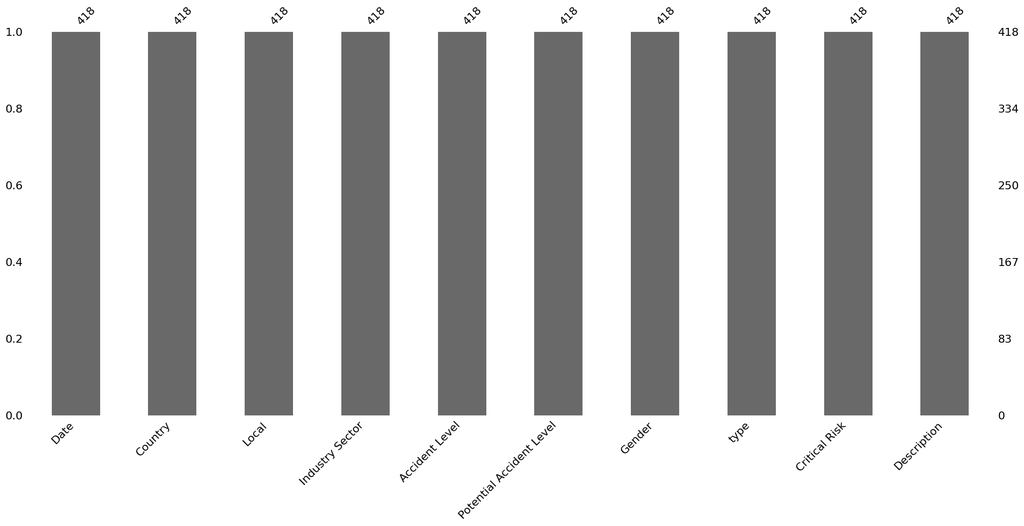

```python
#Visualize missing values using Missingno Library
mino.bar(df)
```

**Below are the activities performed in Data cleansing:**

1) Removed unwanted column (Unnamed: 0).

2) Renamed few columns ('Data', 'Countries', 'Genre', 'Employee or Third Party')

3) Found seven duplicate records in the data. Dropped them.

4) There are no outliers in the dataset.

5) There are no missing values in dataset.

6) After data cleansing we have 418 rows and 10 columns.

**Step 3: Data preprocessing (NLP Preprocessing techniques)**

```python
#Extract day, month , year from date column
#Apply lambda function to get  these columns
df['Date'] = pd.to_datetime(df['Date'])
df['Year'] = df.Date.apply(lambda x : x.year)
df['Month'] = df.Date.apply(lambda x : x.month)
df['Day'] = df.Date.apply(lambda x : x.day)
df['Weekday'] = df.Date.apply(lambda x : x.day_name())
df['WeekofYear'] = df.Date.apply(lambda x : x.weekofyear)
```

```python
#Check top five records
df.head()
```

|  | Date | Country | Local | Industry Sector | Accident Level | Potential Accident Level | Gender | type | Critical Risk | Description | Year | Month | Day | Weekday | WeekofYear |
| --- | --- | --- | --- | --- | --- | --- | --- | --- | --- | --- | --- | --- | --- | --- | --- |
| 0 | 2016-01-01 | Country_01 | Local_01 | Mining | I | IV | Male | Third Party | Pressed | While removing the drill rod of the Jumbo 08 f... | 2016 | 1 | 1 | Friday | 53 |
| 1 | 2016-01-02 | Country_02 | Local_02 | Mining | I | IV | Male | Employee | Pressurized Systems | During the activation of a sodium sulphide pum... | 2016 | 1 | 2 | Saturday | 53 |
| 2 | 2016-01-06 | Country_01 | Local_03 | Mining | I | III | Male | Third Party (Remote) | Manual Tools | In the sub-station MILPO located at level +170... | 2016 | 1 | 6 | Wednesday | 1 |
| 3 | 2016-01-08 | Country_01 | Local_04 | Mining | I | I | Male | Third Party | Others | Being 9:45 am. approximately in the Nv. 1880 C... | 2016 | 1 | 8 | Friday | 1 |
| 4 | 2016-01-10 | Country_01 | Local_04 | Mining | IV | IV | Male | Third Party | Others | Approximately at 11:45 a.m. in circumstances t... | 2016 | 1 | 10 | Sunday | 1 |

```python
#Get Season
# function to create month variable into seasons
def month2seasons(x):
    if x in [9, 10, 11]:
        season = 'Spring'
    elif x in [12, 1, 2]:
        season = 'Summer'
    elif x in [3, 4, 5]:
        season = 'Autumn'
    elif x in [6, 7, 8]:
        season = 'Winter'
    return season
```

```python
df['Season'] = df['Month'].apply(month2seasons)
#Print top three records
df.head(3)
```

|  | Date | Country | Local | Industry Sector | Accident Level | Potential Accident Level | Gender | type | Critical Risk | Description | Year | Month | Day | Weekday | WeekofYear | Season |
| --- | --- | --- | --- | --- | --- | --- | --- | --- | --- | --- | --- | --- | --- | --- | --- | --- |
| 0 | 2016-01-01 | Country_01 | Local_01 | Mining | I | IV | Male | Third Party | Pressed | While removing the drill rod of the Jumbo 08 f... | 2016 | 1 | 1 | Friday | 53 | Summer |
| 1 | 2016-01-02 | Country_02 | Local_02 | Mining | I | IV | Male | Employee | Pressurized Systems | During the activation of a sodium sulphide pum... | 2016 | 1 | 2 | Saturday | 53 | Summer |
| 2 | 2016-01-06 | Country_01 | Local_03 | Mining | I | III | Male | Third Party (Remote) | Manual Tools | In the sub-station MILPO located at level +170... | 2016 | 1 | 6 | Wednesday | 1 | Summer |

```python
# Check the Correlation
df.corr()
```

|  | Year | Month | Day | WeekofYear |
| --- | --- | --- | --- | --- |
| Year | 1.000000 | -0.416621 | -0.001982 | -0.418798 |
| Month | -0.416621 | 1.000000 | 0.002133 | 0.964295 |
| Day | -0.001982 | 0.002133 | 1.000000 | 0.060982 |
| WeekofYear | -0.418798 | 0.964295 | 0.060982 | 1.000000 |

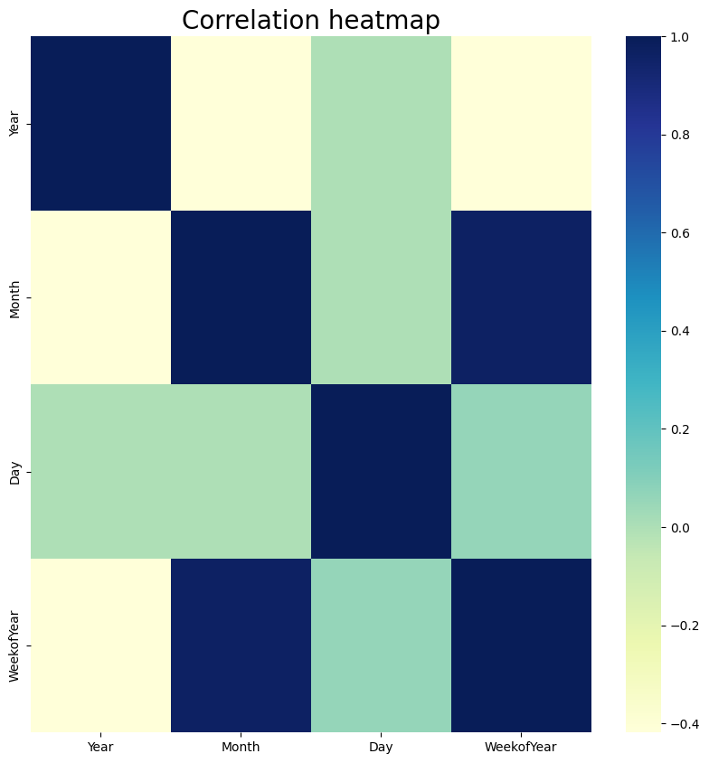

```python
# heatmap to get correlation
plt.rcParams['figure.figsize'] = (10, 10)
sns.heatmap(df.corr(), cmap = "YlGnBu")
plt.title('Correlation heatmap', fontsize = 20)
```

WeekofYear feature is having very high positive correlation with Month feature.

```
------------------------------------------------------------
Value Counts for `Country` label
------------------------------------------------------------
Country_01 count: 248 i.e. 59.0%
Country_02 count: 129 i.e. 31.0%
Country_03 count: 41 i.e. 10.0%
------------------------------------------------------------
Distributon of `Country` label
------------------------------------------------------------
```

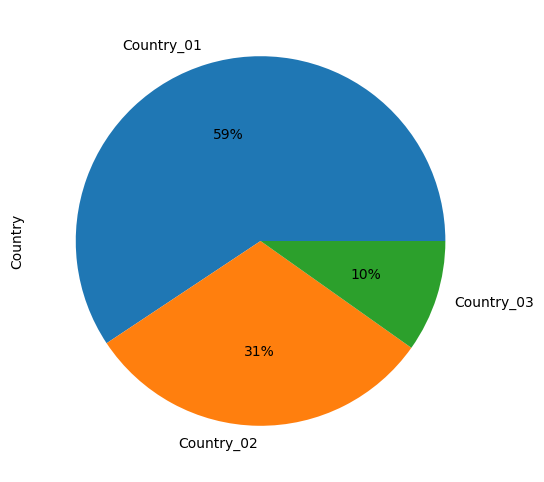

```python
#Univariate Analysis of country
print('--'*30); print('Value Counts for `Country` label'); print('--'*30)
#Get the total row count
total_row_count = df.shape[0]
#Get the count of individual country type
country_01_count = df[df.Country == 'Country_01'].shape[0]
country_02_count = df[df.Country == 'Country_02'].shape[0]
country_03_count = df[df.Country == 'Country_03'].shape[0]

print(f'Country_01 count: {country_01_count} i.e. {round(country_01_count/total_row_count*100, 0)}%')
print(f'Country_02 count: {country_02_count} i.e. {round(country_02_count/total_row_count*100, 0)}%')
print(f'Country_03 count: {country_03_count} i.e. {round(country_03_count/total_row_count*100, 0)}%')

print('--'*30); print('Distributon of `Country` label'); print('--'*30)
#Visualize using Pie chart
_ = df['Country'].value_counts().plot(kind = 'pie', autopct = '%.0f%%', labels = ['Country_01', 'Country_02', 'Country_03'], figsize = (15, 6))
```

Percentage of accidents occurred in Country_01 is 59% and 31% in Country_02 and 10% in Country_03.

Country_01 has higher percentage of accidents (more than 50%).

```python
#Univariate analysis of accidents occured in particular seasons.
print('--'*30); print('Incidents occoured in each seasons'); print('--'*30)
#Get the count of individual country type
summer_01_count = df[df.Season == 'Summer'].shape[0]
print(f'summer_count:',summer_01_count)

spring_01_count = df[df.Season == 'Spring'].shape[0]
print(f'spring_count:',spring_01_count)

autumn_01_count = df[df.Season == 'Autumn'].shape[0]
print(f'autumn_count:',autumn_01_count)

winter_01_count = df[df.Season == 'Winter'].shape[0]
print(f'winter_count:',winter_01_count)
```

```
------------------------------------------------------------
Incidents occoured in each seasons
------------------------------------------------------------
summer_count: 123
spring_count: 58
autumn_count: 141
winter_count: 96
```

There are less incidents occured in spring season and more incidents occured in Autumn season. Even in summer and winter seasons there are good amount of incidents.

```python
#Univariate analysis of Gender
print('--'*30); print('Incidents gender wise'); print('--'*30)
#Get the count of individual Gender type
male_01_count = df[df.Gender == 'Male'].shape[0]
print(f'male_count:',male_01_count)
female_01_count = df[df.Gender == 'Female'].shape[0]
print(f'female_count:',female_01_count)
print('--'*30); print('Percentage of Incidents gender wise'); print('--'*30)
print(f'male_count: {round(male_01_count/total_row_count*100, 0)}%')
print(f'female_count: {round(female_01_count/total_row_count*100, 0)}%')
```

```
------------------------------------------------------------
Incidents gender wise
------------------------------------------------------------
male_count: 396
female_count: 22
------------------------------------------------------------
Percentage of Incidents gender wise
------------------------------------------------------------
male_count: 95.0%
female_count: 5.0%
```

Proportion of accident levels in each gender is not equal.Males have a very higher accident levels than females.

```python
#Univariate analysis of accidents occured in Local.
local_count = df['Local'].value_counts(normalize=True) * 100

hv.extension('bokeh')
hv.Bars(local_count).opts(title="Local Count", color="#8888ff", xlabel="Locals", ylabel="Percentage", yformatter='%d%%')\
                .opts(opts.Bars(width=700, height=300,tools=['hover'],show_grid=True))
```

Local_03 location has the **highest number** of plants, while Local_09 and Local_11 have lowest.

```python
#Univariate analysis of accidents occured in individual Industry Sector
print('--'*30); print('Value Counts for `Industry Sector` label'); print('--'*30)
#Get the count of individual Industry Sector type
Mining_count = df[df['Industry Sector'] == 'Mining'].shape[0]
Metals_count = df[df['Industry Sector'] == 'Metals'].shape[0]
Others_count = df[df['Industry Sector'] == 'Others'].shape[0]

print(f'Mining count: {Mining_count} i.e. {round(Mining_count/total_row_count*100, 0)}%')
print(f'Metals count: {Metals_count} i.e. {round(Metals_count/total_row_count*100, 0)}%')
print(f'Others count: {Others_count} i.e. {round(Others_count/total_row_count*100, 0)}%')

print('--'*30); print('Distributon of `Industry Sector` label'); print('--'*30)

sector_count = np.round(df['Industry Sector'].value_counts(normalize=True) * 100)
hv.extension('bokeh')
hv.Bars(sector_count).opts(title="Industry Sector Count", color="#8888ff", xlabel="Sectors", ylabel="Percentage", yformatter='%d%%')\
                .opts(opts.Bars(width=700, height=300,tools=['hover'],show_grid=True))
```

```
------------------------------------------------------------
Value Counts for `Industry Sector` label
------------------------------------------------------------
Mining count: 237 i.e. 57.0%
Metals count: 134 i.e. 32.0%
Others count: 47 i.e. 11.0%
------------------------------------------------------------
Distributon of `Industry Sector` label
------------------------------------------------------------
```

57% manufacturing plants belongs to Mining sector.

32% manufacturing plants belongs to Metals sector.

11% manufacturing plants belongs to Others sector.

```python
#Univariate analysis of Accident Level and Potential Accident Level
print('--'*30); print('Value Counts for `Accident Level` label'); print('--'*40)
#Get the count of individual Accident Levels
I_acc_count = df[df['Accident Level'] == 'I'].shape[0]
II_acc_count = df[df['Accident Level'] == 'II'].shape[0]
III_acc_count = df[df['Accident Level'] == 'III'].shape[0]
IV_acc_count = df[df['Accident Level'] == 'IV'].shape[0]
V_acc_count = df[df['Accident Level'] == 'V'].shape[0]
VI_acc_count = df[df['Accident Level'] == 'VI'].shape[0]

print(f'Accident Level - I count: {I_acc_count} i.e. {round(I_acc_count/total_row_count*100, 0)}%')
print(f'Accident Level - II count: {II_acc_count} i.e. {round(II_acc_count/total_row_count*100, 0)}%')
print(f'Accident Level - III count: {III_acc_count} i.e. {round(III_acc_count/total_row_count*100, 0)}%')
print(f'Accident Level - IV count: {IV_acc_count} i.e. {round(IV_acc_count/total_row_count*100, 0)}%')
print(f'Accident Level - V count: {V_acc_count} i.e. {round(V_acc_count/total_row_count*100, 0)}%')
print(f'Accident Level - VI count: {VI_acc_count} i.e. {round(VI_acc_count/total_row_count*100, 0)}%')

print('--'*30); print('Value Counts for `Potential Accident Level'); print('--'*40)
#Get the count of individual Potential Accident Levels
I_pot_acc_count = df[df['Potential Accident Level'] == 'I'].shape[0]
II_pot_acc_count = df[df['Potential Accident Level'] == 'II'].shape[0]
III_pot_acc_count = df[df['Potential Accident Level'] == 'III'].shape[0]
IV_pot_acc_count = df[df['Potential Accident Level'] == 'IV'].shape[0]
V_pot_acc_count = df[df['Potential Accident Level'] == 'V'].shape[0]
VI_pot_acc_count = df[df['Potential Accident Level'] == 'VI'].shape[0]

print(f'Potential Accident Level - I count: {I_pot_acc_count} i.e. {round(I_pot_acc_count/total_row_count*100, 0)}%')
print(f'Potential Accident Level - II count: {II_pot_acc_count} i.e. {round(II_pot_acc_count/total_row_count*100, 0)}%')
print(f'Potential Accident Level - III count: {III_pot_acc_count} i.e. {round(III_pot_acc_count/total_row_count*100, 0)}%')
print(f'Potential Accident Level - IV count: {IV_pot_acc_count} i.e. {round(IV_pot_acc_count/total_row_count*100, 0)}%')
print(f'Potential Accident Level - V count: {V_pot_acc_count} i.e. {round(V_pot_acc_count/total_row_count*100, 0)}%')
print(f'Potential Accident Level - VI count: {VI_pot_acc_count} i.e. {round(VI_pot_acc_count/total_row_count*100, 0)}%')

print('--'*30); print('Distributon of `Accident Level` & `Potential Accident Level` label'); print('--'*40)

ac_level_count = np.round(df['Accident Level'].value_counts(normalize=True) * 100)
pot_ac_level_count = np.round(df['Potential Accident Level'].value_counts(normalize=True) * 100, decimals=1)
ac_pot = pd.concat([ac_level_count, pot_ac_level_count], axis=1,sort=False).fillna(0).rename(columns={'Accident Level':'Accident', 'Potential Accident Level':'Potential'})
ac_pot = pd.melt(ac_pot.reset_index(), ['index']).rename(columns={'index':'Severity', 'variable':'Levels'})

hv.extension('bokeh')
hv.Bars(ac_pot, ['Severity', 'Levels'], 'value').opts(opts.Bars(title="Accident Levels Count", width=700, height=300,tools=['hover'],\
                                                                show_grid=True,xrotation=45, ylabel="Percentage", yformatter='%d%%'))
```

```
------------------------------------------------------------
Value Counts for `Accident Level` label
--------------------------------------------------------------------------------
Accident Level - I count: 309 i.e. 74.0%
Accident Level - II count: 40 i.e. 10.0%
Accident Level - III count: 31 i.e. 7.0%
Accident Level - IV count: 30 i.e. 7.0%
Accident Level - V count: 8 i.e. 2.0%
Accident Level - VI count: 0 i.e. 0.0%
------------------------------------------------------------
Value Counts for `Potential Accident Level
--------------------------------------------------------------------------------
Potential Accident Level - I count: 45 i.e. 11.0%
Potential Accident Level - II count: 95 i.e. 23.0%
Potential Accident Level - III count: 106 i.e. 25.0%
Potential Accident Level - IV count: 141 i.e. 34.0%
Potential Accident Level - V count: 30 i.e. 7.0%
Potential Accident Level - VI count: 1 i.e. 0.0%
------------------------------------------------------------
Distributon of `Accident Level` & `Potential Accident Level` label
--------------------------------------------------------------------------------
```

For all levels , the number of accidents decreases as the Accident Level increases.

For first four levels , the number of accidents increases as the Potential Accident Level increases.

```python
#Univariate analysis of Employee type
print('--'*30); print('Value Counts for `Employee type` label'); print('--'*30)
#Get the count of individual Employee type
third_party_count = df[df['type'] == 'Third Party'].shape[0]
emp_count = df[df['type'] == 'Employee'].shape[0]
third_rem_count = df[df['type'] == 'Third Party (Remote)'].shape[0]

print(f'Third Party count: {third_party_count} i.e. {round(third_party_count/total_row_count*100, 0)}%')
print(f'Employee count: {emp_count} i.e. {round(emp_count/total_row_count*100, 0)}%')
print(f'Third Party (Remote) count: {third_rem_count} i.e. {round(third_rem_count/total_row_count*100, 0)}%')

print('--'*30); print('Distributon of `Employee type` label'); print('--'*30)

emp_type_count = np.round(df['type'].value_counts(normalize=True) * 100)

hv.extension('bokeh')
hv.Bars(emp_type_count).opts(title="Employee type Count", color="#8888ff", xlabel="Type", ylabel="Percentage", yformatter='%d%%')\
                .opts(opts.Bars(width=500, height=300,tools=['hover'],show_grid=True))
```

```
------------------------------------------------------------
Value Counts for `Employee type` label
------------------------------------------------------------
Third Party count: 185 i.e. 44.0%
Employee count: 178 i.e. 43.0%
Third Party (Remote) count: 55 i.e. 13.0%
------------------------------------------------------------
Distributon of `Employee type` label
------------------------------------------------------------
```

43% own empoyees working in this industry.

44% Third party empoyees working in this industry.

13% Third party(Remote) empoyees working in this industry.

```
--------------------------------------------------------------------------------------------------------------
5 random Descriptions and accident_levels from the data where the length of Description is > 100
--------------------------------------------------------------------------------------------------------------
Description: Employee was doing cleaning near the area of the pneumatic conveyor when he was hit by a drop of sulfuric acid on his upper lip.
accident_level: I

Description: The employee of partner company GR reports that she was cutting watermelon when she injured her 2nd chirodactilo of the left hand with the knife.
accident_level: II

Description: In the Raise chamber, when the operator and assistant removed the drilling bar from the 71R drilling machine - weight approx. 500 Kg - holding it at the top with a 2 TM stroke and assisted with jibs to move horizontally, the operator's jib on the bottom slides by moving the top of the d…
accident_level: I

Description: The mincing team was carrying out activities in the city of Juína and was coordinated by mining technician Felipe a time when the mining technician was last in line and more away from the team, was bitten by a blackjack on the left side of his face. There was no allergic manifestation a…
accident_level: I

Description: When checking voltage at the power outlet of the the plug and socket to make sure the connection was correct, when there was a small electrical arc in the power cord, causing a slight burn in the right hand wrist. The protection system acted immediately.
accident_level: I

--------------------------------------------------------------------------------
Distributon of accident_level where the length of Description is > 100
--------------------------------------------------------------------------------
```

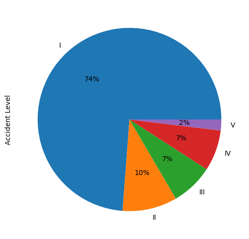

```python
# Checking 5 random Descriptions and accident_levels from the data where the length of headline is > 100
print('--'*55); print('5 random Descriptions and accident_levels from the data where the length of Description is > 100'); print('--'*55)
indexes = list(df.loc[df['Description'].str.len() > 100, 'Description'].index)
rands = random.sample(indexes, 5)
descriptions, accident_levels = list(df.loc[rands, 'Description']), list(df.loc[rands, 'Accident Level'])

_ = [print(f'Description: {description}\naccident_level: {acclevel}\n') for description, acclevel in zip(descriptions, accident_levels)]

print('--'*40); print('Distributon of accident_level where the length of Description is > 100'); print('--'*40)
_ = df.loc[indexes, 'Accident Level'].value_counts().plot(kind = 'pie', autopct = '%.0f%%', labels = ['I', 'II', 'III', 'IV', 'V'], figsize = (10, 6))
```

```
------------------------------------------------------------------------------------------------------------------------
Checking 5 random Descriptions and pot_accident_levels from the data where the length of Description is > 100
------------------------------------------------------------------------------------------------------------------------
Description: In moments that the operator of the Jumbo 2, tried energize your equipment to proceed to the installation of 4 split set at intersection 544 of Nv 3300, remove the lock and opening the electric board of 440V and 400A, and when lifting the thermomagnetic key This makes phase to ground - …
pot_accident_level: V

Description: In circumstances that the collaborator performed the cleaning of the ditch 3570, 0.50 cm deep, removing the pipe of 2 "HDPE material with an estimated weight of 30 Kg. Together with two collaborators, when pushing the tube to drain the dune, the collaborator is hit on the lower right si…
pot_accident_level: II

Description: The employee was performing maintenance of the blower, when the residual water projection occurred on his face. In an attempt to remove PPE, the injured person has had contact with contaminated gloves with the right eye causing irritation.
pot_accident_level: II

Description: Being 11:30 am. approximately, in the Nv. 1940, CX-791. Mr. Francisco - Operator of the Scoop 18, observes a polyethylene pipe thrown on the road, proceeding to lower his equipment and when was found by lifting the pipe to the hook of the right gable, a piece of rock that was suspended …
pot_accident_level: III

Description: At a time when the heavy equipment operator got on the equipment to check the right front headlight (defective) of the scooptram # 181, position on the rim position # 2 his left leg which slides, causing the heavy equipment operator to fall from a height of 0.60 cm
pot_accident_level: IV

--------------------------------------------------------------------------------
Distributon of pot_accident_level where the length of Description is > 100
--------------------------------------------------------------------------------
```

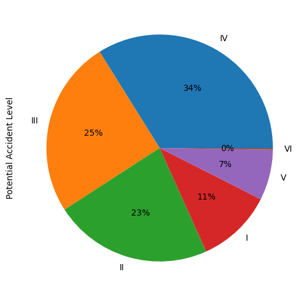

```python
# Checking 5 random Descriptions and Potential accident levels from the data where the length of headline is > 100
print('--'*60); print('Checking 5 random Descriptions and pot_accident_levels from the data where the length of Description is > 100'); print('--'*60)
indexes = list(df.loc[df['Description'].str.len() > 100, 'Description'].index)
rands = random.sample(indexes, 5)
descriptions, pot_accident_levels = list(df.loc[rands, 'Description']), list(df.loc[rands, 'Potential Accident Level'])

_ = [print(f'Description: {descriptin}\npot_accident_level: {pot_acclevel}\n') for descriptin, pot_acclevel in zip(descriptions, pot_accident_levels)]

print('--'*40); print('Distributon of pot_accident_level where the length of Description is > 100'); print('--'*40)
_ = df.loc[indexes, 'Potential Accident Level'].value_counts().plot(kind = 'pie', autopct = '%.0f%%', labels = ['IV', 'III', 'II', 'I', 'V', 'VI'], figsize = (10, 6))
```

```python
#Univariate Analysis for Critical Risk
cr_risk_count = np.round(df['Critical Risk'].value_counts(normalize=True) * 100)
hv.extension('bokeh')
hv.Bars(cr_risk_count[::-1]).opts(title="Critical Risk Count", color="#8888ff", xlabel="Critical Risks", ylabel="Percentage", xformatter='%d%%')\
                .opts(opts.Bars(width=600, height=600,tools=['hover'],show_grid=True,invert_axes=True))
```

Most of the Critical Risks are classified as 'Others' . Hence it will take so much time to analyze risks and reasons why the accidents occur.

```python
#Univariate Analysis of Year and Month
year_count = np.round(df['Year'].value_counts(normalize=True,sort=False) * 100)
year = hv.Bars(year_count).opts(title="Year Count", color="yellow", xlabel="Years")
month_count = np.round(df['Month'].value_counts(normalize=True,sort=False) * 100)
month = hv.Bars(month_count).opts(title="Month Count", color="#8888ff", xlabel="Months") * hv.Curve(month_count).opts(color='red', line_width=3)
hv.extension('bokeh')
(year + month).opts(opts.Bars(width=400, height=300,tools=['hover'],show_grid=True, ylabel="Percentage", yformatter='%d%%'))
```

Accidents are recorded from 1st Jan 2016 to 9th July 2017 in every month.

There are high number of accidents in 2016 and less in 2017.

Number of Accidents are high in the beggining of year and gradually decreasing later.

```python
#Bi-variate Analysis of Gender and Industry Sector
f = lambda x : np.round(x/x.sum() * 100)
em_gen = df.groupby(['Gender','Industry Sector'])['Industry Sector'].count().unstack().apply(f, axis=1)
hv.extension('bokeh')
hv.Bars(pd.melt(em_gen.reset_index(), ['Gender']), ['Gender','Industry Sector'], 'value').opts(opts.Bars(title="Industry Sector by Gender Count", width=800, height=300,tools=['hover'],\
                                                                show_grid=True,xrotation=0, ylabel="Percentage", yformatter='%d%%'))
```

Proportion of any Industry Sector employees in each gender are not equal.

There are more Female employees in Metals and more Male employees in Mining sector.

```python
#converting description to lower case
df['Description'] = df['Description'].str.lower()
```

```python
#Print top five records
df.head()
```

|  | Date | Country | Local | Industry Sector | Accident Level | Potential Accident Level | Gender | type | Critical Risk | Description | Year | Month | Day | Weekday | WeekofYear | Season |
| --- | --- | --- | --- | --- | --- | --- | --- | --- | --- | --- | --- | --- | --- | --- | --- | --- |
| 0 | 2016-01-01 | Country_01 | Local_01 | Mining | I | IV | Male | Third Party | Pressed | while removing the drill rod of the jumbo 08 f... | 2016 | 1 | 1 | Friday | 53 | Summer |
| 1 | 2016-01-02 | Country_02 | Local_02 | Mining | I | IV | Male | Employee | Pressurized Systems | during the activation of a sodium sulphide pum... | 2016 | 1 | 2 | Saturday | 53 | Summer |
| 2 | 2016-01-06 | Country_01 | Local_03 | Mining | I | III | Male | Third Party (Remote) | Manual Tools | in the sub-station milpo located at level +170... | 2016 | 1 | 6 | Wednesday | 1 | Summer |
| 3 | 2016-01-08 | Country_01 | Local_04 | Mining | I | I | Male | Third Party | Others | being 9:45 am. approximately in the nv. 1880 c... | 2016 | 1 | 8 | Friday | 1 | Summer |
| 4 | 2016-01-10 | Country_01 | Local_04 | Mining | IV | IV | Male | Third Party | Others | approximately at 11:45 a.m. in circumstances t... | 2016 | 1 | 10 | Sunday | 1 | Summer |

```python
#Removing Special Characters:
df['Description'] = df['Description'].apply(lambda x: re.sub(r'[^a-zA-Z0-9\s]', '', x))
```

```python
#Stop words
df['Description'] = df['Description'].apply(lambda x: ' '.join([word for word in word_tokenize(x) if word.lower() not in stop_words]))
```

```python
#Lemmatizer
lemmatizer = WordNetLemmatizer()
df['Description'] = df['Description'].apply(lambda x: ' '.join([lemmatizer.lemmatize(word) for word in word_tokenize(x)]))
```

```python
#Tokenize
#Created new column for Tokenized text
df['tokenized_text'] = df['Description'].apply(word_tokenize)
print(df['tokenized_text'])
```

```
0      [removing, drill, rod, jumbo, 08, maintenance,...
1      [activation, sodium, sulphide, pump, piping, u...
2      [substation, milpo, located, level, 170, colla...
3      [945, approximately, nv, 1880, cx695, ob7, per...
4      [approximately, 1145, circumstance, mechanic, ...
                             ...
420    [approximately, 500, approximately, lifting, k...
421    [collaborator, moved, infrastructure, office, ...
422    [environmental, monitoring, activity, area, em...
423    [employee, performed, activity, stripping, cat...
424    [1000, assistant, cleaned, floor, module, e, c...
Name: tokenized_text, Length: 418, dtype: object
```

```python
# Initialize the Porter Stemmer
stemmer = PorterStemmer()

# Define a function to perform stemming on the 'text' column
def stem_words(words):
    return [stemmer.stem(word) for word in words]

# Define a function to perform stemming on the 'text' column
def stem_words(words):
    return [stemmer.stem(word) for word in words]

# Apply the function to the 'text' column and create a new column 'stemmed_text'
df['stemmed_messages'] = df['Description'].apply(stem_words)
```

```python
# initialize lemmatizer
lemmatizer = WordNetLemmatizer()

# define function to lemmatize tokens
def lemmatize_tokens(tokens):
    # convert POS tag to WordNet format
    def get_wordnet_pos(word):
        tag = nltk.pos_tag([word])[0][1][0].upper()
        tag_dict = {"J": wordnet.ADJ,
                    "N": wordnet.NOUN,
                    "V": wordnet.VERB,
                    "R": wordnet.ADV}
        return tag_dict.get(tag, wordnet.NOUN)

    # lemmatize tokens
    lemmas = [lemmatizer.lemmatize(token, get_wordnet_pos(token)) for token in tokens]

    # return lemmatized tokens as a list
    return lemmas

# apply lemmatization function to column of dataframe
df['lemmatized_messages'] = df['Description'].apply(lemmatize_tokens)
```

```python
#Print top five records
df.head()
```

|  | Date | Country | Local | Industry Sector | Accident Level | Potential Accident Level | Gender | type | Critical Risk | Description | Year | Month | Day | Weekday | WeekofYear | Season | tokenized_text | stemmed_messages | lemmatized_messages |
| --- | --- | --- | --- | --- | --- | --- | --- | --- | --- | --- | --- | --- | --- | --- | --- | --- | --- | --- | --- |
| 0 | 2016-01-01 | Country_01 | Local_01 | Mining | I | IV | Male | Third Party | Pressed | removing drill rod jumbo 08 maintenance superv... | 2016 | 1 | 1 | Friday | 53 | Summer | [removing, drill, rod, jumbo, 08, maintenance,... | [r, e, m, o, v, i, n, g, , d, r, i, l, l, , ... | [r, e, m, o, v, i, n, g, , d, r, i, l, l, , ... |
| 1 | 2016-01-02 | Country_02 | Local_02 | Mining | I | IV | Male | Employee | Pressurized Systems | activation sodium sulphide pump piping uncoupl... | 2016 | 1 | 2 | Saturday | 53 | Summer | [activation, sodium, sulphide, pump, piping, u... | [a, c, t, i, v, a, t, i, o, n, , s, o, d, i, ... | [a, c, t, i, v, a, t, i, o, n, , s, o, d, i, ... |
| 2 | 2016-01-06 | Country_01 | Local_03 | Mining | I | III | Male | Third Party (Remote) | Manual Tools | substation milpo located level 170 collaborato... | 2016 | 1 | 6 | Wednesday | 1 | Summer | [substation, milpo, located, level, 170, colla... | [s, u, b, s, t, a, t, i, o, n, , m, i, l, p, ... | [s, u, b, s, t, a, t, i, o, n, , m, i, l, p, ... |
| 3 | 2016-01-08 | Country_01 | Local_04 | Mining | I | I | Male | Third Party | Others | 945 approximately nv 1880 cx695 ob7 personnel ... | 2016 | 1 | 8 | Friday | 1 | Summer | [945, approximately, nv, 1880, cx695, ob7, per... | [9, 4, 5, , a, p, p, r, o, x, i, m, a, t, e, ... | [9, 4, 5, , a, p, p, r, o, x, i, m, a, t, e, ... |
| 4 | 2016-01-10 | Country_01 | Local_04 | Mining | IV | IV | Male | Third Party | Others | approximately 1145 circumstance mechanic antho... | 2016 | 1 | 10 | Sunday | 1 | Summer | [approximately, 1145, circumstance, mechanic, ... | [a, p, p, r, o, x, i, m, a, t, e, l, y, , 1, ... | [a, p, p, r, o, x, i, m, a, t, e, l, y, , 1, ... |

```python
#Dummy variables encoding
Country_dummies = pd.get_dummies(df['Country'], columns=["Country"], drop_first=True)
Local_dummies = pd.get_dummies(df['Local'], columns=["Local"], drop_first=True)
Gender_dummies = pd.get_dummies(df['Gender'], columns=["Gender"], drop_first=True)
IS_dummies = pd.get_dummies(df['Industry Sector'], columns=['Industry Sector'], prefix='IS', drop_first=True)
EmpType_dummies = pd.get_dummies(df['type'], columns=['type'], prefix='EmpType', drop_first=True)
CR_dummies = pd.get_dummies(df['Critical Risk'], columns=['Critical Risk'], prefix='CR', drop_first=True)

# Merge the above dataframe with the original dataframe df
df = df.join(Country_dummies.reset_index(drop=True)).join(Local_dummies.reset_index(drop=True)).join(Gender_dummies.reset_index(drop=True)).join(IS_dummies.reset_index(drop=True)).join(EmpType_dummies.reset_index(drop=True)).join(CR_dummies.reset_index(drop=True))
#Print top three records
df.head(3)
```

|  | Date | Country | Local | Industry Sector | Accident Level | Potential Accident Level | Gender | type | Critical Risk | Description | ... | CR_Projection | CR_Projection of fragments | CR_Projection/Burning | CR_Projection/Choco | CR_Projection/Manual Tools | CR_Suspended Loads | CR_Traffic | CR_Vehicles and Mobile Equipment | CR_Venomous Animals | CR_remains of choco |
| --- | --- | --- | --- | --- | --- | --- | --- | --- | --- | --- | --- | --- | --- | --- | --- | --- | --- | --- | --- | --- | --- |
| 0 | 2016-01-01 | Country_01 | Local_01 | Mining | I | IV | Male | Third Party | Pressed | removing drill rod jumbo 08 maintenance superv... | ... | 0.0 | 0.0 | 0.0 | 0.0 | 0.0 | 0.0 | 0.0 | 0.0 | 0.0 | 0.0 |
| 1 | 2016-01-02 | Country_02 | Local_02 | Mining | I | IV | Male | Employee | Pressurized Systems | activation sodium sulphide pump piping uncoupl... | ... | 0.0 | 0.0 | 0.0 | 0.0 | 0.0 | 0.0 | 0.0 | 0.0 | 0.0 | 0.0 |
| 2 | 2016-01-06 | Country_01 | Local_03 | Mining | I | III | Male | Third Party (Remote) | Manual Tools | substation milpo located level 170 collaborato... | ... | 0.0 | 0.0 | 0.0 | 0.0 | 0.0 | 0.0 | 0.0 | 0.0 | 0.0 | 0.0 |

3 rows × 69 columns

```python
# Label encoding
df['Season'] = df['Season'].replace('Summer', 'aSummer').replace('Autumn', 'bAutumn').replace('Winter', 'cWinter').replace('Spring', 'dSpring')
df['Season'] = LabelEncoder().fit_transform(df['Season']).astype(np.int8)

df['Weekday'] = df['Weekday'].replace('Monday', 'aMonday').replace('Tuesday', 'bTuesday').replace('Wednesday', 'cWednesday').replace('Thursday', 'dThursday').replace('Friday', 'eFriday').replace('Saturday', 'fSaturday').replace('Sunday', 'gSunday')
df['Weekday'] = LabelEncoder().fit_transform(df['Weekday']).astype(np.int8)
```

```python
#Print top five records
df.head()
```

|  | Date | Country | Local | Industry Sector | Accident Level | Potential Accident Level | Gender | type | Critical Risk | Description | ... | CR_Projection | CR_Projection of fragments | CR_Projection/Burning | CR_Projection/Choco | CR_Projection/Manual Tools | CR_Suspended Loads | CR_Traffic | CR_Vehicles and Mobile Equipment | CR_Venomous Animals | CR_remains of choco |
| --- | --- | --- | --- | --- | --- | --- | --- | --- | --- | --- | --- | --- | --- | --- | --- | --- | --- | --- | --- | --- | --- |
| 0 | 2016-01-01 | Country_01 | Local_01 | Mining | I | IV | Male | Third Party | Pressed | removing drill rod jumbo 08 maintenance superv... | ... | 0.0 | 0.0 | 0.0 | 0.0 | 0.0 | 0.0 | 0.0 | 0.0 | 0.0 | 0.0 |
| 1 | 2016-01-02 | Country_02 | Local_02 | Mining | I | IV | Male | Employee | Pressurized Systems | activation sodium sulphide pump piping uncoupl... | ... | 0.0 | 0.0 | 0.0 | 0.0 | 0.0 | 0.0 | 0.0 | 0.0 | 0.0 | 0.0 |
| 2 | 2016-01-06 | Country_01 | Local_03 | Mining | I | III | Male | Third Party (Remote) | Manual Tools | substation milpo located level 170 collaborato... | ... | 0.0 | 0.0 | 0.0 | 0.0 | 0.0 | 0.0 | 0.0 | 0.0 | 0.0 | 0.0 |
| 3 | 2016-01-08 | Country_01 | Local_04 | Mining | I | I | Male | Third Party | Others | 945 approximately nv 1880 cx695 ob7 personnel ... | ... | 0.0 | 0.0 | 0.0 | 0.0 | 0.0 | 0.0 | 0.0 | 0.0 | 0.0 | 0.0 |
| 4 | 2016-01-10 | Country_01 | Local_04 | Mining | IV | IV | Male | Third Party | Others | approximately 1145 circumstance mechanic antho... | ... | 0.0 | 0.0 | 0.0 | 0.0 | 0.0 | 0.0 | 0.0 | 0.0 | 0.0 | 0.0 |

5 rows × 69 columns

```python
#Get the length of each line in Description and find the maximum length
print('--'*45); print('Get the length of each line, find the maximum length and print the maximum length line');
print('Length of line ranges from 61 to 672.'); print('--'*45)

# Get length of each line
df['line_length'] = df['Description'].str.len()

print('Minimum line length: {}'.format(df['line_length'].min()))
print('Maximum line length: {}'.format(df['line_length'].max()))
print('Line with maximum length: {}'.format(df[df['line_length'] == df['line_length'].max()]['Description'].values[0]))
```

```
------------------------------------------------------------------------------------------
Get the length of each line, find the maximum length and print the maximum length line
Length of line ranges from 61 to 672.
------------------------------------------------------------------------------------------
Minimum line length: 61
Maximum line length: 672
Line with maximum length: level 3490 gallery 239 holding activity bolter equipment 24 operator performs drilling first hole support right gable 7footdeep drill end drill rod break leaving thread inside drilling machine shank operator assistant decide make two empty percussion attempt free thread sha…
```

```python
##Get the minimum and maximum number of words  in Description
print('--'*45); print('Get the number of words, find the maximum number of words and print the maximum number of words');
print('Number of words ranges from 9 to 98.'); print('--'*45)

# Get length of each line
df['no_words'] = df['Description'].apply(lambda x: len(x.split(' ')))

print('Minimum number of words: {}'.format(df['no_words'].min()))
print('Maximum number of words: {}'.format(df['no_words'].max()))
print('Line with maximum number of words: {}'.format(df[df['no_words'] == df['no_words'].max()]['Description'].values[0]))
```

```
------------------------------------------------------------------------------------------
Get the number of words, find the maximum number of words and print the maximum number of words
Number of words ranges from 9 to 98.
------------------------------------------------------------------------------------------
Minimum number of words: 9
Maximum number of words: 98
Line with maximum number of words: performing sleeve removal maneuver hole 600 meter deep general da silva pressed one side locking nut rod together jack hold entire weight rod maneuver locking procedure effective weight rod secured steel wire rope probe winch moment driller pedro released brake win…
```

**Below are the summary of Data pre-processing:**

For length of accident description greater than 100 , 74% of data is captured in low accident level.

For length of accident description greater than 100 , 34% of data is captured in high medium potential accident level.

For length of accident description greater than 100 , 25% of data is captured in medium potential accident level.

For length of accident description greater than 100 , 23% of data is captured in low potential accident level.

Below are the NLP Pre - processing applied on Accident Description : Converting to lower case. Removing special characters. Removing stop words. Lemmatization.

After pre-processing steps, Description column has below min and max line length and number of words:

Minimum line length: 61

Maximum line length: 672

Minimum number of words: 9

Maximum number of words: 98

**Step 4 : Data preparation - Cleansed data in .xlsx or .csv file**

```python
#Check the info of cleansed data
df.info()
```

```
<class 'pandas.core.frame.DataFrame'>
Int64Index: 418 entries, 0 to 424
Data columns (total 69 columns):
 #   Column                                        Non-Null Count  Dtype
---  ------                                        --------------  -----
 0   Date                                          418 non-null    datetime64[ns]
 1   Country                                       418 non-null    object
 2   Local                                         418 non-null    object
 3   Industry Sector                               418 non-null    object
 4   Accident Level                                418 non-null    object
 5   Potential Accident Level                      418 non-null    object
 6   Gender                                        418 non-null    object
 7   type                                          418 non-null    object
 8   Critical Risk                                 418 non-null    object
 9   Description                                   418 non-null    object
```

[output cut: 61 more lines]

```python
# Removing the columns which are not required for modelling
df=df.drop(columns=['Date'],axis=1)
df=df.drop(['tokenized_text', 'stemmed_messages','lemmatized_messages'], axis=1)
df=df.drop(['line_length', 'no_words'], axis=1)
```

```python
#Since we have already  created dummy variable encoding hence deleting these columns
df=df.drop(['Country','Local','Industry Sector','Gender','type','Critical Risk'], axis=1)
```

```python
#Check the info
df.info()
```

```
<class 'pandas.core.frame.DataFrame'>
Int64Index: 418 entries, 0 to 424
Data columns (total 59 columns):
 #   Column                                        Non-Null Count  Dtype
---  ------                                        --------------  -----
 0   Accident Level                                418 non-null    object
 1   Potential Accident Level                      418 non-null    object
 2   Description                                   418 non-null    object
 3   Year                                          418 non-null    int64
 4   Month                                         418 non-null    int64
 5   Day                                           418 non-null    int64
 6   Weekday                                       418 non-null    int8
 7   WeekofYear                                    418 non-null    int64
 8   Season                                        418 non-null    int8
 9   Country_02                                    411 non-null    float64
```

[output cut: 51 more lines]

```python
#Check for NULL values in cleansed data
print('Check for NULL values :\n',df.isnull().sum(),'\n')
#Null values are not in the main columns. Only the encoded columns have NULL values
```

```
Check for NULL values :
 Accident Level                                  0
Potential Accident Level                        0
Description                                     0
Year                                            0
Month                                           0
Day                                             0
Weekday                                         0
WeekofYear                                      0
Season                                          0
Country_02                                      7
Country_03                                      7
Local_02                                        7
Local_03                                        7
Local_04                                        7
Local_05                                        7
Local_06                                        7
Local_07                                        7
Local_08                                        7
Local_09                                        7
Local_10                                        7
Local_11                                        7
Local_12                                        7
Male                                            7
IS_Mining                                       7
IS_Others                                       7
EmpType_Third Party                             7
EmpType_Third Party (Remote)                    7
CR_Bees                                         7
CR_Blocking and isolation of energies           7
CR_Burn                                         7
CR_Chemical substances                          7
CR_Confined space                               7
CR_Cut                                          7
CR_Electrical Shock                             7
CR_Electrical installation                      7
CR_Fall                                         7
CR_Fall prevention                              7
CR_Fall prevention (same level)                 7
CR_Individual protection equipment              7
CR_Liquid Metal                                 7
CR_Machine Protection                           7
CR_Manual Tools                                 7
CR_Others                                       7
CR_Plates                                       7
CR_Poll                                         7
CR_Power lock                                   7
CR_Pressed                                      7
CR_Pressurized Systems                          7
CR_Pressurized Systems / Chemical Substances    7
CR_Projection                                   7
CR_Projection of fragments                      7
CR_Projection/Burning                           7
CR_Projection/Choco                             7
CR_Projection/Manual Tools                      7
CR_Suspended Loads                              7
CR_Traffic                                      7
CR_Vehicles and Mobile Equipment                7
CR_Venomous Animals                             7
CR_remains of choco                             7
dtype: int64
```

```python
#Check the row and column count
print('Row Count -',df.shape[0])
print('Column count - ',df.shape[1])
```

```
Row Count - 418
Column count -  59
```

```python
#Print first five records
df.head()
```

|  | Accident Level | Potential Accident Level | Description | Year | Month | Day | Weekday | WeekofYear | Season | Country_02 | ... | CR_Projection | CR_Projection of fragments | CR_Projection/Burning | CR_Projection/Choco | CR_Projection/Manual Tools | CR_Suspended Loads | CR_Traffic | CR_Vehicles and Mobile Equipment | CR_Venomous Animals | CR_remains of choco |
| --- | --- | --- | --- | --- | --- | --- | --- | --- | --- | --- | --- | --- | --- | --- | --- | --- | --- | --- | --- | --- | --- |
| 0 | I | IV | removing drill rod jumbo 08 maintenance superv... | 2016 | 1 | 1 | 4 | 53 | 0 | 0.0 | ... | 0.0 | 0.0 | 0.0 | 0.0 | 0.0 | 0.0 | 0.0 | 0.0 | 0.0 | 0.0 |
| 1 | I | IV | activation sodium sulphide pump piping uncoupl... | 2016 | 1 | 2 | 5 | 53 | 0 | 1.0 | ... | 0.0 | 0.0 | 0.0 | 0.0 | 0.0 | 0.0 | 0.0 | 0.0 | 0.0 | 0.0 |
| 2 | I | III | substation milpo located level 170 collaborato... | 2016 | 1 | 6 | 2 | 1 | 0 | 0.0 | ... | 0.0 | 0.0 | 0.0 | 0.0 | 0.0 | 0.0 | 0.0 | 0.0 | 0.0 | 0.0 |
| 3 | I | I | 945 approximately nv 1880 cx695 ob7 personnel ... | 2016 | 1 | 8 | 4 | 1 | 0 | 0.0 | ... | 0.0 | 0.0 | 0.0 | 0.0 | 0.0 | 0.0 | 0.0 | 0.0 | 0.0 | 0.0 |
| 4 | IV | IV | approximately 1145 circumstance mechanic antho... | 2016 | 1 | 10 | 6 | 1 | 0 | 0.0 | ... | 0.0 | 0.0 | 0.0 | 0.0 | 0.0 | 0.0 | 0.0 | 0.0 | 0.0 | 0.0 |

5 rows × 59 columns

```python
#Check for duplicate records
df.duplicated().sum()
```

```
0
```

```python
#Check for unique values
df.nunique()
```

```
Accident Level                                    5
Potential Accident Level                          6
Description                                     411
Year                                              2
Month                                            12
Day                                              31
Weekday                                           7
WeekofYear                                       53
Season                                            4
Country_02                                        2
Country_03                                        2
Local_02                                          2
Local_03                                          2
Local_04                                          2
Local_05                                          2
Local_06                                          2
Local_07                                          2
Local_08                                          2
Local_09                                          2
Local_10                                          2
Local_11                                          2
Local_12                                          2
Male                                              2
IS_Mining                                         2
IS_Others                                         2
EmpType_Third Party                               2
EmpType_Third Party (Remote)                      2
CR_Bees                                           2
CR_Blocking and isolation of energies             2
CR_Burn                                           2
CR_Chemical substances                            2
CR_Confined space                                 2
CR_Cut                                            2
CR_Electrical Shock                               2
CR_Electrical installation                        2
CR_Fall                                           2
CR_Fall prevention                                2
CR_Fall prevention (same level)                   2
CR_Individual protection equipment                2
CR_Liquid Metal                                   2
CR_Machine Protection                             2
CR_Manual Tools                                   2
CR_Others                                         2
CR_Plates                                         2
CR_Poll                                           2
CR_Power lock                                     2
CR_Pressed                                        2
CR_Pressurized Systems                            2
CR_Pressurized Systems / Chemical Substances      2
CR_Projection                                     2
CR_Projection of fragments                        2
CR_Projection/Burning                             2
CR_Projection/Choco                               2
CR_Projection/Manual Tools                        2
CR_Suspended Loads                                2
CR_Traffic                                        2
CR_Vehicles and Mobile Equipment                  2
CR_Venomous Animals                               2
CR_remains of choco                               2
dtype: int64
```

```python
#Check Std deviation
cols = df.select_dtypes([np.number]).columns
std = df[cols].std()
cols_to_drop = std[std==0].index
cols_to_drop
print('There are',len(cols_to_drop),'columns with std deviation Zero')
```

```
There are 0 columns with std deviation Zero
```

```python
#Copy the dataframe to csv and xlsx
#Copy to xlsx
df.to_excel('/content/drive/MyDrive/CAPSTONE_PROJECT/industrial_safety_and_health_database.xlsx', index=False)
#Copy to csv
df.to_csv('/content/drive/MyDrive/CAPSTONE_PROJECT/industrial_safety_and_health_database.csv', index=False)
```

**Step 5: Design train and test basic machine learning classifiers**

```python
#Import data from newly created csv
data = pd.read_csv('/content/drive/MyDrive/CAPSTONE_PROJECT/industrial_safety_and_health_database.csv')
```

```python
#print five records
data.head()
```

|  | Accident Level | Potential Accident Level | Description | Year | Month | Day | Weekday | WeekofYear | Season | Country_02 | ... | CR_Projection | CR_Projection of fragments | CR_Projection/Burning | CR_Projection/Choco | CR_Projection/Manual Tools | CR_Suspended Loads | CR_Traffic | CR_Vehicles and Mobile Equipment | CR_Venomous Animals | CR_remains of choco |
| --- | --- | --- | --- | --- | --- | --- | --- | --- | --- | --- | --- | --- | --- | --- | --- | --- | --- | --- | --- | --- | --- |
| 0 | I | IV | removing drill rod jumbo 08 maintenance superv... | 2016 | 1 | 1 | 4 | 53 | 0 | 0.0 | ... | 0.0 | 0.0 | 0.0 | 0.0 | 0.0 | 0.0 | 0.0 | 0.0 | 0.0 | 0.0 |
| 1 | I | IV | activation sodium sulphide pump piping uncoupl... | 2016 | 1 | 2 | 5 | 53 | 0 | 1.0 | ... | 0.0 | 0.0 | 0.0 | 0.0 | 0.0 | 0.0 | 0.0 | 0.0 | 0.0 | 0.0 |
| 2 | I | III | substation milpo located level 170 collaborato... | 2016 | 1 | 6 | 2 | 1 | 0 | 0.0 | ... | 0.0 | 0.0 | 0.0 | 0.0 | 0.0 | 0.0 | 0.0 | 0.0 | 0.0 | 0.0 |
| 3 | I | I | 945 approximately nv 1880 cx695 ob7 personnel ... | 2016 | 1 | 8 | 4 | 1 | 0 | 0.0 | ... | 0.0 | 0.0 | 0.0 | 0.0 | 0.0 | 0.0 | 0.0 | 0.0 | 0.0 | 0.0 |
| 4 | IV | IV | approximately 1145 circumstance mechanic antho... | 2016 | 1 | 10 | 6 | 1 | 0 | 0.0 | ... | 0.0 | 0.0 | 0.0 | 0.0 | 0.0 | 0.0 | 0.0 | 0.0 | 0.0 | 0.0 |

5 rows × 59 columns

```python
#Function to fit model and obtain accuracy and classification Report
def model_accuracy(data,X_train,X_test,y_train,y_test):
  data.fit(X_train,y_train)
  #Predict test
  preds_data=data.predict(X_test)
  #Predict train
  preds_data_train=data.predict(X_train)
  acc_test=accuracy_score(y_test,preds_data)
  acc_train=accuracy_score(y_train,preds_data_train)
  acc_train_cc=classification_report(y_train,preds_data_train)
  acc_test_cc=classification_report(y_test,preds_data)
  model_cm_test = confusion_matrix(y_test, preds_data)
  model_cm_train = confusion_matrix(y_train, preds_data_train)
  return acc_test,acc_train,acc_test_cc,acc_train_cc,model_cm_test,model_cm_train
```

```python
#Funtion to concatinate model results
def results_concat(resdata,testacc,trainacc,method):
  temp_df=pd.DataFrame({'Method':[method],'Accuracy of Test data':testacc,'Accuracy of Train data':trainacc})
  res_df=pd.concat([resdata,temp_df])
  res_df=res_df[['Method','Accuracy of Test data','Accuracy of Train data']]
  return res_df
```

```python
#Split train and test data. We will take test data size 0.2
X_train, X_test, y_train, y_test = train_test_split(data['Description'], data['Potential Accident Level'].values, test_size=0.2, random_state=42)
```

```python
#Bag of words feature extraction
from sklearn.feature_extraction.text import CountVectorizer
vectorizer = CountVectorizer(binary=True, ngram_range=(1, 2))
X_train_bow = vectorizer.fit_transform(X_train)
X_test_bow = vectorizer.transform(X_test)
```

```python
#Build model codes which in turn calls functions to fit data , obtain accuracy and concatenate model results
# Define a Standard Scaler to normalize inputs
scaler = StandardScaler(with_mean=False)
# Set up the k-fold cross-validation
kfold2 = StratifiedKFold(n_splits=3, shuffle=True, random_state=0)
```

```python
#Logistic Regression
logistic = LogisticRegression()
pipe = Pipeline(steps=[("scaler", scaler), ("logistic", logistic)])
param_grid = [
    { 'logistic__C' : np.logspace(-4, 4, 4),
    'logistic__solver' : ['lbfgs','newton-cg','liblinear','sag','saga'],
    'logistic__max_iter' : [100, 1000, 2500, 5500, 7000, 7500],
    'logistic__tol' : [0.1]
    }
]
PCAGrid_lg = GridSearchCV(pipe,param_grid,cv=kfold2, n_jobs=2)
acc_test,acc_train,acc_test_cc,acc_train_cc,model_cm_test,model_cm_train=model_accuracy(PCAGrid_lg,X_train_bow,X_test_bow,y_train,y_test)
```

```python
print('\n Logistic Regression Results for Train data:')
print('\n Accuracy of train data: ',acc_train)
print('\n Classification Report for train data \n',acc_train_cc)
print('\nConfusion Matrix for train data')
sns.heatmap(model_cm_train, annot=True,  fmt='.2f', xticklabels = ["I", "II", "III", "IV", "V"] , yticklabels = ["I", "II", "III", "IV", "V"] )
plt.ylabel('Actual')
plt.xlabel('Predicted')
plt.show()
```

[output not shown]

```
 Logistic Regression Results for Train data:

 Accuracy of train data:  1.0

 Classification Report for train data
               precision    recall  f1-score   support

           I       1.00      1.00      1.00        36
          II       1.00      1.00      1.00        78
         III       1.00      1.00      1.00        79
          IV       1.00      1.00      1.00       115
           V       1.00      1.00      1.00        25
          VI       1.00      1.00      1.00         1

    accuracy                           1.00       334
   macro avg       1.00      1.00      1.00       334
weighted avg       1.00      1.00      1.00       334


Confusion Matrix for train data
```

```
 Logistic Regression Results for Test data:

 Accuracy of test data:  0.44047619047619047

 Classification Report for test data
               precision    recall  f1-score   support

           I       1.00      0.33      0.50         9
          II       0.50      0.29      0.37        17
         III       0.50      0.22      0.31        27
          IV       0.40      0.88      0.55        26
           V       0.00      0.00      0.00         5

    accuracy                           0.44        84
   macro avg       0.48      0.35      0.35        84
weighted avg       0.49      0.44      0.40        84


Confusion Matrix for test data
```

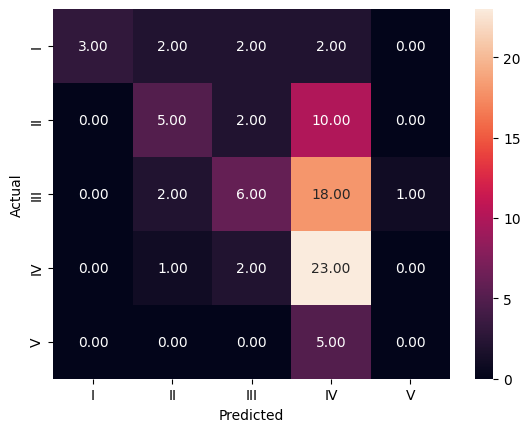

```python
print('\n Logistic Regression Results for Test data:')
print('\n Accuracy of test data: ',acc_test)
print('\n Classification Report for test data \n',acc_test_cc)
print('\nConfusion Matrix for test data')
sns.heatmap(model_cm_test, annot=True,  fmt='.2f', xticklabels = ["I", "II", "III", "IV", "V"] , yticklabels = ["I", "II", "III", "IV", "V"] )
plt.ylabel('Actual')
plt.xlabel('Predicted')
plt.show()
```

```python
#Create new data frame and add the accuracy results to the newly created results_df dataframe
results_df=pd.DataFrame({'Method':['Logistic Regression'],'Accuracy of Test data':acc_test,'Accuracy of Train data':acc_train})
results_df=results_df[['Method','Accuracy of Test data','Accuracy of Train data']]
```

**Summary on Logistic Regression results**:

Training data seems to be overfitting.

Performance matrix of Test data:

Accuracy : 0.44

Precision : 0.49

Recall : 0.44

F1-score: 0.40

```python
#Decision Tree
DecTree = DecisionTreeClassifier()
pipe = Pipeline(steps=[("scaler", scaler), ("logistic", DecTree)])
param_grid = [
    { 'logistic__max_depth' : [3],
    'logistic__min_samples_leaf' : [5],
    'logistic__criterion' : ["entropy"],
    'logistic__random_state' : [100]
    }
]
PCAGrid_dt = GridSearchCV(pipe, param_grid,cv=kfold2, n_jobs=2)
acc_test,acc_train,acc_test_cc,acc_train_cc,model_cm_test,model_cm_train=model_accuracy(PCAGrid_dt,X_train_bow,X_test_bow,y_train,y_test)
```

```
 Decision Tree Results for Train data:

 Accuracy of train data:  0.39820359281437123

 Classification Report for train data
               precision    recall  f1-score   support

           I       1.00      0.50      0.67        36
          II       0.00      0.00      0.00        78
         III       0.00      0.00      0.00        79
          IV       0.36      1.00      0.53       115
           V       0.00      0.00      0.00        25
          VI       0.00      0.00      0.00         1

    accuracy                           0.40       334
   macro avg       0.23      0.25      0.20       334
weighted avg       0.23      0.40      0.26       334


Confusion Matrix for train data
```

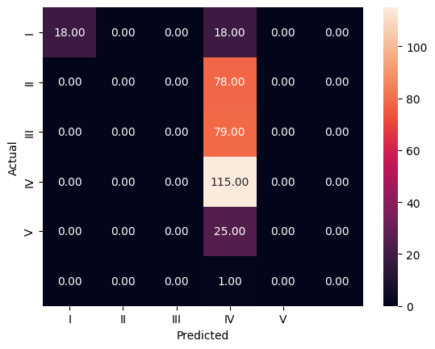

```python
print('\n Decision Tree Results for Train data:')
print('\n Accuracy of train data: ',acc_train)
print('\n Classification Report for train data \n',acc_train_cc)
print('\nConfusion Matrix for train data')
sns.heatmap(model_cm_train, annot=True,  fmt='.2f', xticklabels = ["I", "II", "III", "IV", "V"] , yticklabels = ["I", "II", "III", "IV", "V"] )
plt.ylabel('Actual')
plt.xlabel('Predicted')
plt.show()
```

```
 Decision Tree Results for Test data:

 Accuracy of test data:  0.34523809523809523

 Classification Report for test data
               precision    recall  f1-score   support

           I       1.00      0.33      0.50         9
          II       0.00      0.00      0.00        17
         III       0.00      0.00      0.00        27
          IV       0.32      1.00      0.49        26
           V       0.00      0.00      0.00         5

    accuracy                           0.35        84
   macro avg       0.26      0.27      0.20        84
weighted avg       0.21      0.35      0.20        84


Confusion Matrix for test data
```

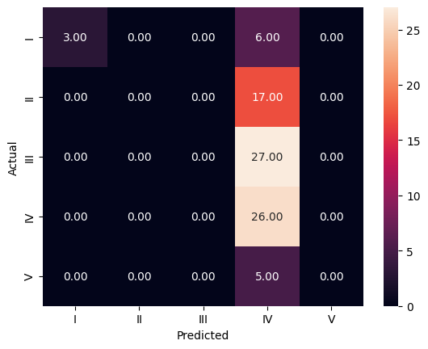

```python
print('\n Decision Tree Results for Test data:')
print('\n Accuracy of test data: ',acc_test)
print('\n Classification Report for test data \n',acc_test_cc)
print('\nConfusion Matrix for test data')
sns.heatmap(model_cm_test, annot=True,  fmt='.2f', xticklabels = ["I", "II", "III", "IV", "V"] , yticklabels = ["I", "II", "III", "IV", "V"] )
plt.ylabel('Actual')
plt.xlabel('Predicted')
plt.show()
```

```python
#Add the accuracy results to results_df dataframe
results_df=results_concat(results_df,acc_test,acc_train,'Decision Tree')
```

**Summary on Decesion Tree results**:

Performance matrix of Train data:

Accuracy : 0.40

Precision : 0.23

Recall : 0.40

F1-score: 0.26

Performance matrix of Test data:

Accuracy : 0.35

Precision : 0.21

Recall : 0.35

F1-score: 0.20

```python
#Random Forest
rfcl = RandomForestClassifier()
pipe = Pipeline(steps=[("scaler", scaler), ("logistic", rfcl)])
param_grid = [
    {
    'logistic__n_estimators' : [50],
     }
]
PCAGrid_rf = GridSearchCV(pipe, param_grid,cv=kfold2, n_jobs=2)
acc_test,acc_train,acc_test_cc,acc_train_cc,model_cm_test,model_cm_train=model_accuracy(PCAGrid_rf,X_train_bow,X_test_bow,y_train,y_test)
```

```python
print('\n Random Forest Results for Train data:')
print('\n Accuracy of train data: ',acc_train)
print('\n Classification Report for train data \n',acc_train_cc)
print('\nConfusion Matrix for train data')
sns.heatmap(model_cm_train, annot=True,  fmt='.2f', xticklabels = ["I", "II", "III", "IV", "V"] , yticklabels = ["I", "II", "III", "IV", "V"] )
plt.ylabel('Actual')
plt.xlabel('Predicted')
plt.show()
```

[output not shown]

```
 Random Forest Results for Train data:

 Accuracy of train data:  1.0

 Classification Report for train data
               precision    recall  f1-score   support

           I       1.00      1.00      1.00        36
          II       1.00      1.00      1.00        78
         III       1.00      1.00      1.00        79
          IV       1.00      1.00      1.00       115
           V       1.00      1.00      1.00        25
          VI       1.00      1.00      1.00         1

    accuracy                           1.00       334
   macro avg       1.00      1.00      1.00       334
weighted avg       1.00      1.00      1.00       334


Confusion Matrix for train data
```

```
 Random Forest Results for Test data:

 Accuracy of test data:  0.44047619047619047

 Classification Report for test data
               precision    recall  f1-score   support

           I       1.00      0.33      0.50         9
          II       0.50      0.47      0.48        17
         III       0.44      0.15      0.22        27
          IV       0.39      0.85      0.54        26
           V       0.00      0.00      0.00         5

    accuracy                           0.44        84
   macro avg       0.47      0.36      0.35        84
weighted avg       0.47      0.44      0.39        84


Confusion Matrix for test data
```

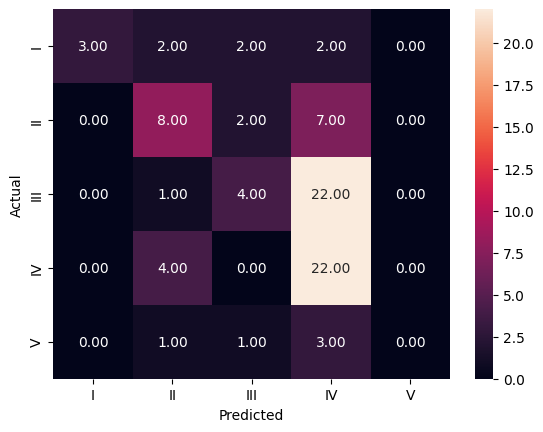

```python
print('\n Random Forest Results for Test data:')
print('\n Accuracy of test data: ',acc_test)
print('\n Classification Report for test data \n',acc_test_cc)
print('\nConfusion Matrix for test data')
sns.heatmap(model_cm_test, annot=True,  fmt='.2f', xticklabels = ["I", "II", "III", "IV", "V"] , yticklabels = ["I", "II", "III", "IV", "V"] )
plt.ylabel('Actual')
plt.xlabel('Predicted')
plt.show()
```

```python
#Add the accuracy results to results_df dataframe
results_df=results_concat(results_df,acc_test,acc_train,'Random Forest')
```

**Summary on Random Forest results**:

Training data seems to be overfitting.

Performance matrix of Test data:

Accuracy : 0.44

Precision : 0.47

Recall : 0.44

F1-score: 0.39

```python
#Ada Boost Classifier
adab = AdaBoostClassifier()
pipe = Pipeline(steps=[("scaler", scaler), ("logistic", adab)])
param_grid = [
    {
    'logistic__n_estimators' : [100],
     'logistic__learning_rate' : [0.1],
    'logistic__random_state' : [22]
    }
]
PCAGrid_ad = GridSearchCV(pipe, param_grid,cv=kfold2, n_jobs=2)
acc_test,acc_train,acc_test_cc,acc_train_cc,model_cm_test,model_cm_train=model_accuracy(PCAGrid_ad,X_train_bow,X_test_bow,y_train,y_test)
```

```
 AdaBoost Results for Train data:

 Accuracy of train data:  0.4311377245508982

 Classification Report for train data
               precision    recall  f1-score   support

           I       1.00      0.33      0.50        36
          II       0.30      0.08      0.12        78
         III       0.38      0.06      0.11        79
          IV       0.41      1.00      0.58       115
           V       0.83      0.20      0.32        25
          VI       1.00      1.00      1.00         1

    accuracy                           0.43       334
   macro avg       0.65      0.45      0.44       334
weighted avg       0.47      0.43      0.33       334


Confusion Matrix for train data
```

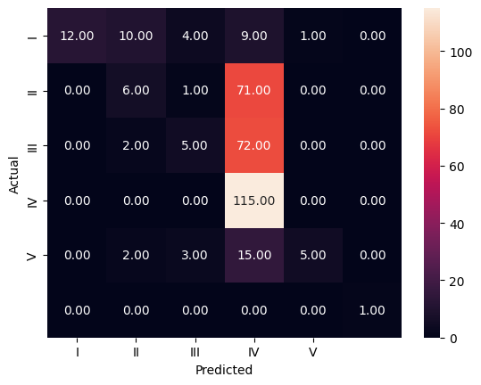

```python
print('\n AdaBoost Results for Train data:')
print('\n Accuracy of train data: ',acc_train)
print('\n Classification Report for train data \n',acc_train_cc)
print('\nConfusion Matrix for train data')
sns.heatmap(model_cm_train, annot=True,  fmt='.2f', xticklabels = ["I", "II", "III", "IV", "V"] , yticklabels = ["I", "II", "III", "IV", "V"] )
plt.ylabel('Actual')
plt.xlabel('Predicted')
plt.show()
```

```
 AdaBoost Results for Test data:

 Accuracy of test data:  0.34523809523809523

 Classification Report for test data
               precision    recall  f1-score   support

           I       1.00      0.22      0.36         9
          II       0.00      0.00      0.00        17
         III       0.33      0.04      0.07        27
          IV       0.34      0.96      0.50        26
           V       0.50      0.20      0.29         5

    accuracy                           0.35        84
   macro avg       0.43      0.28      0.24        84
weighted avg       0.35      0.35      0.23        84


Confusion Matrix for test data
```

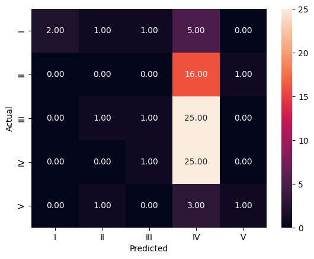

```python
print('\n AdaBoost Results for Test data:')
print('\n Accuracy of test data: ',acc_test)
print('\n Classification Report for test data \n',acc_test_cc)
print('\nConfusion Matrix for test data')
sns.heatmap(model_cm_test, annot=True,  fmt='.2f', xticklabels = ["I", "II", "III", "IV", "V"] , yticklabels = ["I", "II", "III", "IV", "V"] )
plt.ylabel('Actual')
plt.xlabel('Predicted')
plt.show()
```

```python
#Add the accuracy results to results_df dataframe
results_df=results_concat(results_df,acc_test,acc_train,'Adaboost')
```

**Summary on Adaboost results**:

Performance matrix of Train data:

Accuracy : 0.43

Precision : 0.47

Recall : 0.43

F1-score: 0.33

Performance matrix of Test data:

Accuracy : 0.35

Precision : 0.35

Recall : 0.35

F1-score: 0.23

```python
#Bagging with decision tree
bagg = BaggingClassifier()
pipe = Pipeline(steps=[("scaler", scaler), ("logistic", bagg)])
param_grid = [
    {
    'logistic__n_estimators' : [50],
    'logistic__max_samples' : [0.7],
    'logistic__bootstrap' : [True],
    'logistic__oob_score' : [True],
    'logistic__random_state' : [22]
    }
]
PCAGrid_bg = GridSearchCV(pipe, param_grid,cv=kfold2, n_jobs=2)
acc_test,acc_train,acc_test_cc,acc_train_cc,model_cm_test,model_cm_train=model_accuracy(PCAGrid_bg,X_train_bow,X_test_bow,y_train,y_test)
```

```
 Bagging with Decision Tree Results for Train data:

 Accuracy of train data:  0.9940119760479041

 Classification Report for train data
               precision    recall  f1-score   support

           I       1.00      1.00      1.00        36
          II       1.00      1.00      1.00        78
         III       1.00      0.97      0.99        79
          IV       0.98      1.00      0.99       115
           V       1.00      1.00      1.00        25
          VI       1.00      1.00      1.00         1

    accuracy                           0.99       334
   macro avg       1.00      1.00      1.00       334
weighted avg       0.99      0.99      0.99       334


Confusion Matrix for Train data
```

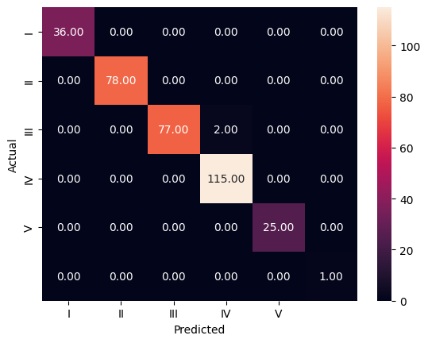

```python
print('\n Bagging with Decision Tree Results for Train data:')
print('\n Accuracy of train data: ',acc_train)
print('\n Classification Report for train data \n',acc_train_cc)
print('\nConfusion Matrix for Train data')
sns.heatmap(model_cm_train, annot=True,  fmt='.2f', xticklabels = ["I", "II", "III", "IV", "V"] , yticklabels = ["I", "II", "III", "IV", "V"] )
plt.ylabel('Actual')
plt.xlabel('Predicted')
plt.show()
```

```
 Bagging with Decision Tree Results for Test data:

 Accuracy of test data:  0.47619047619047616

 Classification Report for test data
               precision    recall  f1-score   support

           I       1.00      0.33      0.50         9
          II       0.58      0.41      0.48        17
         III       0.54      0.26      0.35        27
          IV       0.41      0.88      0.56        26
           V       0.00      0.00      0.00         5

    accuracy                           0.48        84
   macro avg       0.51      0.38      0.38        84
weighted avg       0.53      0.48      0.44        84


Confusion Matrix for test data
```

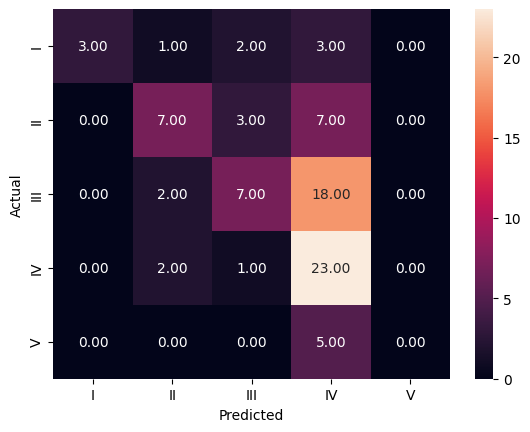

```python
print('\n Bagging with Decision Tree Results for Test data:')
print('\n Accuracy of test data: ',acc_test)
print('\n Classification Report for test data \n',acc_test_cc)
print('\nConfusion Matrix for test data')
sns.heatmap(model_cm_test, annot=True,  fmt='.2f', xticklabels = ["I", "II", "III", "IV", "V"] , yticklabels = ["I", "II", "III", "IV", "V"] )
plt.ylabel('Actual')
plt.xlabel('Predicted')
plt.show()
```

```python
#Add the accuracy results to results_df dataframe
results_df=results_concat(results_df,acc_test,acc_train,'Bagging (Decision Tree)')
```

**Summary on Bagging (Decision Tree) results**:

Training data seems to be overfitting.

Performance matrix of Test data:

Accuracy : 0.48

Precision : 0.53

Recall : 0.48

F1-score: 0.44

```python
#Bagging with Naive Bayes
X_train_bow1=X_train_bow.toarray()
X_test_bow1=X_test_bow.toarray()
pipe = Pipeline(steps=[("scaler", scaler), ("logistic", bagg)])
param_grid = [
    {
    'logistic__n_estimators' : [50],
    'logistic__base_estimator' : [GaussianNB()],
    'logistic__max_samples' : [0.7],
    'logistic__bootstrap' : [True],
    'logistic__oob_score' : [True],
    'logistic__random_state' : [22]
    }
]
PCAGrid_bgnv = GridSearchCV(pipe, param_grid,cv=kfold2, n_jobs=2)
acc_test,acc_train,acc_test_cc,acc_train_cc,model_cm_test,model_cm_train=model_accuracy(PCAGrid_bgnv,X_train_bow1,X_test_bow1,y_train,y_test)
```

[output not shown]

[output cut: 93 more lines]

[output not shown]

```
 Bagging with NB Classifier Results for Train data:

 Accuracy of train data:  0.9101796407185628

 Classification Report for train data
               precision    recall  f1-score   support

           I       1.00      0.97      0.99        36
          II       0.98      0.83      0.90        78
         III       0.99      0.86      0.92        79
          IV       0.80      0.99      0.89       115
           V       1.00      0.84      0.91        25
          VI       1.00      1.00      1.00         1

    accuracy                           0.91       334
   macro avg       0.96      0.92      0.93       334
weighted avg       0.93      0.91      0.91       334


Confusion Matrix for train data
```

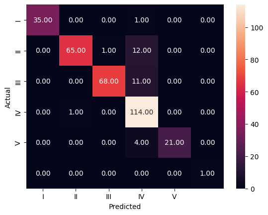

```python
print('\n Bagging with NB Classifier Results for Train data:')
print('\n Accuracy of train data: ',acc_train)
print('\n Classification Report for train data \n',acc_train_cc)
print('\nConfusion Matrix for train data')
sns.heatmap(model_cm_train, annot=True,  fmt='.2f', xticklabels = ["I", "II", "III", "IV", "V"] , yticklabels = ["I", "II", "III", "IV", "V"] )
plt.ylabel('Actual')
plt.xlabel('Predicted')
plt.show()
```

```
 Bagging with NB Classifier Results for Test data:

 Accuracy of test data:  0.4166666666666667

 Classification Report for test data
               precision    recall  f1-score   support

           I       0.50      0.33      0.40         9
          II       0.30      0.18      0.22        17
         III       0.50      0.19      0.27        27
          IV       0.43      0.92      0.59        26
           V       0.00      0.00      0.00         5

    accuracy                           0.42        84
   macro avg       0.35      0.32      0.30        84
weighted avg       0.41      0.42      0.36        84


Confusion Matrix for test data
```

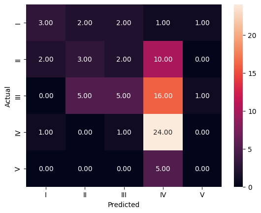

```python
print('\n Bagging with NB Classifier Results for Test data:')
print('\n Accuracy of test data: ',acc_test)
print('\n Classification Report for test data \n',acc_test_cc)
print('\nConfusion Matrix for test data')
sns.heatmap(model_cm_test, annot=True,  fmt='.2f', xticklabels = ["I", "II", "III", "IV", "V"] , yticklabels = ["I", "II", "III", "IV", "V"] )
plt.ylabel('Actual')
plt.xlabel('Predicted')
plt.show()
```

```python
#Add the accuracy results to results_df dataframe
results_df=results_concat(results_df,acc_test,acc_train,'Bagging (NB Classifier)')
```

**Summary on Bagging (NB Classifier) results**:

Training data seems to be overfitting.

Performance matrix of Test data:

Accuracy : 0.42

Precision : 0.41

Recall : 0.42

F1-score: 0.36

```python
#Bagging Logistic Regression
param_grid = [
    {
    'logistic__n_estimators' : [50],
    'logistic__base_estimator' : [LogisticRegression()],
    'logistic__max_samples' : [0.7],
    'logistic__bootstrap' : [True],
    'logistic__oob_score' : [True],
    'logistic__random_state' : [22]
    }
]
PCAGrid_bglg = GridSearchCV(pipe, param_grid,cv=kfold2, n_jobs=2)
acc_test,acc_train,acc_test_cc,acc_train_cc,model_cm_test,model_cm_train=model_accuracy(PCAGrid_bglg,X_train_bow,X_test_bow,y_train,y_test)
```

[output not shown]

[output cut: 323 more lines]

[output not shown]

```python
print('\n Bagging with Logistic Regression Results for Train data:')
print('\n Accuracy of train data: ',acc_train)
print('\n Classification Report for train data \n',acc_train_cc)
print('\nConfusion Matrix for train data')
sns.heatmap(model_cm_train, annot=True,  fmt='.2f', xticklabels = ["I", "II", "III", "IV", "V"] , yticklabels = ["I", "II", "III", "IV", "V"] )
plt.ylabel('Actual')
plt.xlabel('Predicted')
plt.show()
```

[output not shown]

```
 Bagging with Logistic Regression Results for Train data:

 Accuracy of train data:  1.0

 Classification Report for train data
               precision    recall  f1-score   support

           I       1.00      1.00      1.00        36
          II       1.00      1.00      1.00        78
         III       1.00      1.00      1.00        79
          IV       1.00      1.00      1.00       115
           V       1.00      1.00      1.00        25
          VI       1.00      1.00      1.00         1

    accuracy                           1.00       334
   macro avg       1.00      1.00      1.00       334
weighted avg       1.00      1.00      1.00       334


Confusion Matrix for train data
```

```
 Bagging with Logistic Regression Results for Test data:

 Accuracy of test data:  0.4166666666666667

 Classification Report for test data
               precision    recall  f1-score   support

           I       1.00      0.22      0.36         9
          II       0.50      0.29      0.37        17
         III       0.43      0.11      0.18        27
          IV       0.38      0.96      0.55        26
           V       0.00      0.00      0.00         5

    accuracy                           0.42        84
   macro avg       0.46      0.32      0.29        84
weighted avg       0.47      0.42      0.34        84


Confusion Matrix for test data
```

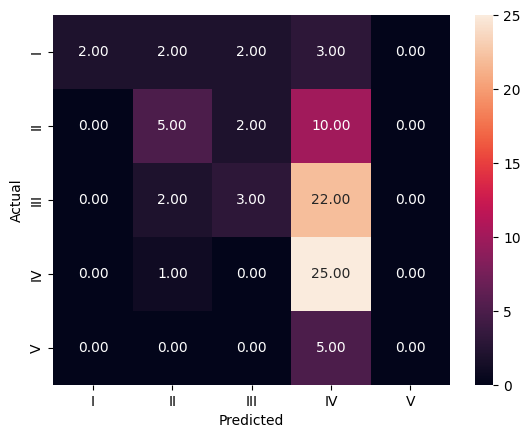

```python
print('\n Bagging with Logistic Regression Results for Test data:')
print('\n Accuracy of test data: ',acc_test)
print('\n Classification Report for test data \n',acc_test_cc)
print('\nConfusion Matrix for test data')
sns.heatmap(model_cm_test, annot=True,  fmt='.2f', xticklabels = ["I", "II", "III", "IV", "V"] , yticklabels = ["I", "II", "III", "IV", "V"] )
plt.ylabel('Actual')
plt.xlabel('Predicted')
plt.show()
```

```python
#Add the accuracy results to results_df dataframe
results_df=results_concat(results_df,acc_test,acc_train,'Bagging (LogReg Classifier)')
```

**Summary on Bagging (LogReg Classifier) results**:

Training data seems to be overfitting.

Performance matrix of Test data:

Accuracy : 0.42

Precision : 0.47

Recall : 0.42

F1-score: 0.34

```python
#Gradient Boosting Classifier
gb = GradientBoostingClassifier()
pipe = Pipeline(steps=[("scaler", scaler), ("logistic", gb)])
param_grid = [
    {
    'logistic__n_estimators' : [50],
    'logistic__learning_rate' : [0.1],
    'logistic__random_state' : [22]
    }
]
PCAGrid_gb = GridSearchCV(pipe, param_grid,cv=kfold2, n_jobs=2)
acc_test,acc_train,acc_test_cc,acc_train_cc,model_cm_test,model_cm_train=model_accuracy(PCAGrid_gb,X_train_bow,X_test_bow,y_train,y_test)
```

```python
print('\n Gradient Boost Results for Train data:')
print('\n Accuracy of train data: ',acc_train)
print('\n Classification Report for train data \n',acc_train_cc)
print('\nConfusion Matrix for train data')
sns.heatmap(model_cm_train, annot=True,  fmt='.2f', xticklabels = ["I", "II", "III", "IV", "V"] , yticklabels = ["I", "II", "III", "IV", "V"] )
plt.ylabel('Actual')
plt.xlabel('Predicted')
plt.show()
```

[output not shown]

```
 Gradient Boost Results for Train data:

 Accuracy of train data:  1.0

 Classification Report for train data
               precision    recall  f1-score   support

           I       1.00      1.00      1.00        36
          II       1.00      1.00      1.00        78
         III       1.00      1.00      1.00        79
          IV       1.00      1.00      1.00       115
           V       1.00      1.00      1.00        25
          VI       1.00      1.00      1.00         1

    accuracy                           1.00       334
   macro avg       1.00      1.00      1.00       334
weighted avg       1.00      1.00      1.00       334


Confusion Matrix for train data
```

```
 Gradient Boost Results for Test data:

 Accuracy of test data:  0.34523809523809523

 Classification Report for test data
               precision    recall  f1-score   support

           I       1.00      0.33      0.50         9
          II       0.60      0.18      0.27        17
         III       0.17      0.07      0.10        27
          IV       0.34      0.77      0.47        26
           V       0.20      0.20      0.20         5

    accuracy                           0.35        84
   macro avg       0.46      0.31      0.31        84
weighted avg       0.40      0.35      0.30        84


Confusion Matrix for test data
```

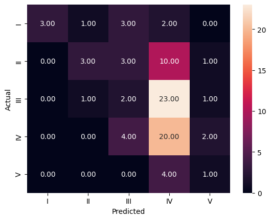

```python
print('\n Gradient Boost Results for Test data:')
print('\n Accuracy of test data: ',acc_test)
print('\n Classification Report for test data \n',acc_test_cc)
print('\nConfusion Matrix for test data')
sns.heatmap(model_cm_test, annot=True,  fmt='.2f', xticklabels = ["I", "II", "III", "IV", "V"] , yticklabels = ["I", "II", "III", "IV", "V"] )
plt.ylabel('Actual')
plt.xlabel('Predicted')
plt.show()
```

```python
#Add the accuracy results to results_df dataframe
results_df=results_concat(results_df,acc_test,acc_train,'Gradient Boost')
```

**Summary on Gradient Boost results**:

Training data seems to be overfitting.

Performance matrix of Test data:

Accuracy : 0.35

Precision : 0.40

Recall : 0.35

F1-score: 0.30

```python
#SVM
from sklearn import svm
sv = svm.SVC()
pipe = Pipeline(steps=[("scaler", scaler), ("logistic", sv)])
param_grid = [
    {'logistic__C': [0.1,1,10,100,1000],
              'logistic__gamma': [1,0,1,0.01,0.001,0.001] ,
              'logistic__kernel':['rbf']
             }
]
PCAGrid_sv = GridSearchCV(pipe, param_grid,cv=kfold2, n_jobs=2)
acc_test,acc_train,acc_test_cc,acc_train_cc,model_cm_test,model_cm_train=model_accuracy(PCAGrid_sv,X_train_bow,X_test_bow,y_train,y_test)
```

```python
print('\n SVM Results for Train data:')
print('\n Accuracy of train data: ',acc_train)
print('\n Classification Report for train data \n',acc_train_cc)
print('\nConfusion Matrix for train data')
sns.heatmap(model_cm_train, annot=True,  fmt='.2f', xticklabels = ["I", "II", "III", "IV", "V"] , yticklabels = ["I", "II", "III", "IV", "V"] )
plt.ylabel('Actual')
plt.xlabel('Predicted')
plt.show()
```

[output not shown]

```
 SVM Results for Train data:

 Accuracy of train data:  1.0

 Classification Report for train data
               precision    recall  f1-score   support

           I       1.00      1.00      1.00        36
          II       1.00      1.00      1.00        78
         III       1.00      1.00      1.00        79
          IV       1.00      1.00      1.00       115
           V       1.00      1.00      1.00        25
          VI       1.00      1.00      1.00         1

    accuracy                           1.00       334
   macro avg       1.00      1.00      1.00       334
weighted avg       1.00      1.00      1.00       334


Confusion Matrix for train data
```

```
 SVM Results for Test data:

 Accuracy of test data:  0.32142857142857145

 Classification Report for test data
               precision    recall  f1-score   support

           I       0.00      0.00      0.00         9
          II       0.00      0.00      0.00        17
         III       1.00      0.04      0.07        27
          IV       0.31      1.00      0.48        26
           V       0.00      0.00      0.00         5

    accuracy                           0.32        84
   macro avg       0.26      0.21      0.11        84
weighted avg       0.42      0.32      0.17        84


Confusion Matrix for test data
```

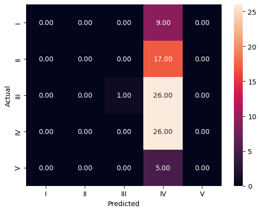

```python
print('\n SVM Results for Test data:')
print('\n Accuracy of test data: ',acc_test)
print('\n Classification Report for test data \n',acc_test_cc)
print('\nConfusion Matrix for test data')
sns.heatmap(model_cm_test, annot=True,  fmt='.2f', xticklabels = ["I", "II", "III", "IV", "V"] , yticklabels = ["I", "II", "III", "IV", "V"] )
plt.ylabel('Actual')
plt.xlabel('Predicted')
plt.show()
```

```python
#Add the accuracy results to results_df dataframe
results_df=results_concat(results_df,acc_test,acc_train,'SVM')
```

**Summary on SVM results**:

Training data seems to be overfitting.

Performance matrix of Test data:

Accuracy : 0.32

Precision : 0.42

Recall : 0.32

F1-score: 0.17

```python
print('\nAccuracy comparisions of each ML models\n')
results_df
```

```
Accuracy comparisions of each ML models
```

|  | Method | Accuracy of Test data | Accuracy of Train data |
| --- | --- | --- | --- |
| 0 | Logistic Regression | 0.440476 | 1.000000 |
| 0 | Decision Tree | 0.345238 | 0.398204 |
| 0 | Random Forest | 0.440476 | 1.000000 |
| 0 | Adaboost | 0.345238 | 0.431138 |
| 0 | Bagging (Decision Tree) | 0.476190 | 0.994012 |
| 0 | Bagging (NB Classifier) | 0.416667 | 0.910180 |
| 0 | Bagging (LogReg Classifier) | 0.416667 | 1.000000 |
| 0 | Gradient Boost | 0.345238 | 1.000000 |
| 0 | SVM | 0.321429 | 1.000000 |

```python
#Copy the results to csv for future use
results_df.to_csv('/content/drive/MyDrive/CAPSTONE_PROJECT/results_ML.csv', index=False)
```

```python
#We have copied all performance metrics in csv. We will export csv to display all the metrics values
results_df_ml = pd.read_csv('/content/drive/MyDrive/CAPSTONE_PROJECT/results_ML_all_metrics.csv')

print('All performance matrics comparision of each ML models\n')
results_df_ml
```

```
All performance matrics comparision of each ML models
```

|  | Method | Accuracy of Test data | Precision of Test data | Recall of Test data | F1-score of Test data | Accuracy of Train data | Precision of Train data | Recall of Train data | F1-score of Train data |
| --- | --- | --- | --- | --- | --- | --- | --- | --- | --- |
| 0 | Logistic Regression | 0.440476 | 0.49 | 0.44 | 0.40 | 1.000000 | 1.00 | 1.00 | 1.00 |
| 1 | Decision Tree | 0.345238 | 0.21 | 0.35 | 0.20 | 0.398204 | 0.23 | 0.40 | 0.26 |
| 2 | Random Forest | 0.440476 | 0.47 | 0.44 | 0.39 | 1.000000 | 1.00 | 1.00 | 1.00 |
| 3 | Adaboost | 0.345238 | 0.35 | 0.35 | 0.23 | 0.431138 | 0.47 | 0.43 | 0.33 |
| 4 | Bagging (Decision Tree) | 0.476190 | 0.53 | 0.48 | 0.44 | 0.994012 | 0.99 | 0.99 | 0.99 |
| 5 | Bagging (NB Classifier) | 0.416667 | 0.41 | 0.42 | 0.36 | 0.910180 | 0.93 | 0.91 | 0.91 |
| 6 | Bagging (LogReg Classifier) | 0.416667 | 0.47 | 0.42 | 0.34 | 1.000000 | 1.00 | 1.00 | 1.00 |
| 7 | Gradient Boost | 0.345238 | 0.40 | 0.35 | 0.30 | 1.000000 | 1.00 | 1.00 | 1.00 |
| 8 | SVM | 0.321429 | 0.42 | 0.32 | 0.17 | 1.000000 | 1.00 | 1.00 | 1.00 |

# **Conclusion after Milestone1**:

We have first imported data. Data cleansing and Data pre-processing is done on the imported data. Exported cleansed data on to the csv and xlsx.

Function is created to build various models.Nine models have been built using this workflow. They are Logistic Regression , Decision Tree, Random Forest , Adaboost , Bagging using decision tree, Naive Bayes Classifier , Logistic Regression classifier and Gradient Boost, SVM.

Accuracy results of both training and test data is calculated and added on to the single dataframe by using functions.

When we compare results below are the observations:

Training data overfitting in most of the models.

By comparing the results from all above methods, both testing and training data accuracy almost matching in Decision Tree and AdaBoost.

Lets now compare Decesion Tree and AdaBoost:

Test Accuracy is same in both the models.

Train Accuracy is slightly high in AdaBoost.

Precision , Recall and F1-score values of train data is high in Adaboost.

Precision and F1-score is higher for test data in AdaBoost as compared to Decision tree.

Recall value of test data is same in both the models.

Since the data is imbalanced , test data accuracy is same for both the models.So we will compare the performance mertrics of each class.

For class I both recall and f1 score is higher in Decision Tree but both models have same precision.

For class II both the models have 0% performance metrics values.

For class III , all the performannce metrics is 0% in Decision Tree but we have 33% precision , 4% recall and 7% F1-score in AdaBoost.

For class IV , recall and precision values are higher in Decision tree but f1-score is higher in AdaBoost.

For class V , all the performannce metrics is 0% in Decision Tree but we have 50% precision , 20% recall and 29% F1-score in AdaBoost.

On comparing all performance metrics, we can select the best model as AdaBoost classifier.

Performance metrics can be improved by using PCA or increase dimensions or by using hyper parameter tuning more efficiently.

# **Milestone 2**

Input: Preprocessed output from Milestone-1

```python
#Reset index of train and test data
X_train.reset_index()
X_test.reset_index()
```

|  | index | Description |
| --- | --- | --- |
| 0 | 321 | performing carpentry work collaborator hit sec... |
| 1 | 324 | maintenance peristaltic pump 02bp0166 change i... |
| 2 | 388 | 1020 hour 05182017 end concentrate truck clean... |
| 3 | 56 | circumstance operator 176 going level 620 leve... |
| 4 | 153 | approximately 545 pm operator paulo operator f... |
| ... | ... | ... |
| 79 | 57 | installing ripper pin tractor d6tn1 ripper sup... |
| 80 | 126 | test soft starter engine belt 03 collaborator ... |
| 81 | 24 | operator g2142 deslaminadora section 75 unlock... |
| 82 | 17 | due overheating 2 bar row 5 cell 7 spark produ... |
| 83 | 66 | carrying activity cutting electrowelded mesh w... |

84 rows × 2 columns

```python
#Sort indices
X_train_bow.sort_indices()
X_test_bow.sort_indices()
```

# **Step 1: Design, train and test Neural networks classifiers**

Here we will build two Neural network models (one simple Neural network and one tuned neural network) and then compare the results.

```python
#Build the neural network using already split train and test data.
nn = Sequential()
# Adding the input layer and the first hidden layer
nn.add(Dense(units = 512, activation = 'relu'))
# Adding the hidden layers
nn.add(Dense(units = 256, activation = 'relu'))
# Adding the hidden layers
nn.add(Dense(units = 100, activation = 'relu'))
# Adding the hidden layers
nn.add(Dense(units = 50, activation = 'relu'))
# Adding the output layer
nn.add(Dense(units = 6, activation = 'softmax'))
```

```python
# Converting the categorical values to one-hot encoding
y_train_new = pd.get_dummies(y_train)
y_test_new = pd.get_dummies(y_test)
```

```python
#Check the shape of both dataset
print('Shape of y_train_new:',y_train_new.shape)
print('Shape of y_test_new:',y_test_new.shape)
```

```
Shape of y_train_new: (334, 6)
Shape of y_test_new: (84, 5)
```

```python
#Add the missing column to test data
# Get missing columns in the training test
missing_cols = set( y_train_new.columns ) - set( y_test_new.columns )
# Add a missing column in test set with default value equal to 0
for c in missing_cols:
    y_test_new[c] = 0
# Ensure the order of column in the test set is in the same order than in train set
y_test_new = y_test_new[y_train_new.columns]
```

```python
#Reset index of train and test data
y_train_new.reset_index()
y_test_new.reset_index()
```

|  | index | I | II | III | IV | V | VI |
| --- | --- | --- | --- | --- | --- | --- | --- |
| 0 | 0 | 1 | 0 | 0 | 0 | 0 | 0 |
| 1 | 1 | 0 | 0 | 0 | 1 | 0 | 0 |
| 2 | 2 | 0 | 0 | 0 | 1 | 0 | 0 |
| 3 | 3 | 0 | 0 | 1 | 0 | 0 | 0 |
| 4 | 4 | 0 | 0 | 0 | 0 | 1 | 0 |
| ... | ... | ... | ... | ... | ... | ... | ... |
| 79 | 79 | 0 | 1 | 0 | 0 | 0 | 0 |
| 80 | 80 | 0 | 0 | 1 | 0 | 0 | 0 |
| 81 | 81 | 0 | 1 | 0 | 0 | 0 | 0 |
| 82 | 82 | 0 | 1 | 0 | 0 | 0 | 0 |
| 83 | 83 | 0 | 1 | 0 | 0 | 0 | 0 |

84 rows × 7 columns

```python
print('Shape of y_test_new:',y_test_new.shape)
```

```
Shape of y_test_new: (84, 6)
```

```python
# Transform Labels into format acceptable by Neural Network
#convert to array
Y_train = np.array(y_train_new)
Y_test = np.array(y_test_new)
```

```python
Y_train.shape
```

```
(334, 6)
```

```python
Y_test.shape
```

```
(84, 6)
```

```python
#Compile the model
nn.compile(optimizer = 'adam', loss = 'categorical_crossentropy', metrics = ['accuracy'])
```

```python
#Add parameters
batch_size = 12
epochs = 5
early_stopping = EarlyStopping(monitor='val_loss', mode='min', verbose=0, patience=3)
#Fit the model
history=nn.fit(X_train_bow.toarray(),Y_train, epochs = epochs, batch_size=batch_size, validation_split = 0.2,callbacks=[early_stopping])
```

```python
#Summary of the model
nn.summary()
```

```
Model: "sequential"
_________________________________________________________________
 Layer (type)                Output Shape              Param #
=================================================================
 dense (Dense)               (None, 512)               5984768

 dense_1 (Dense)             (None, 256)               131328

 dense_2 (Dense)             (None, 100)               25700

 dense_3 (Dense)             (None, 50)                5050

 dense_4 (Dense)             (None, 6)                 306

=================================================================
Total params: 6147152 (23.45 MB)
Trainable params: 6147152 (23.45 MB)
Non-trainable params: 0 (0.00 Byte)
_________________________________________________________________
```

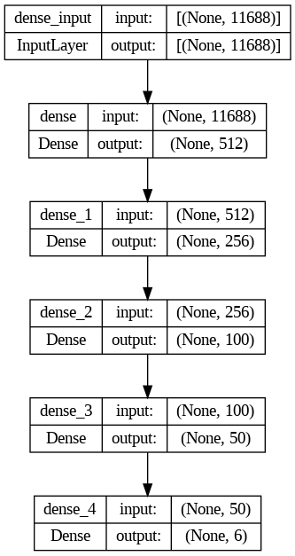

```python
#save model to file
plot_model(nn, to_file='nn_model.png', show_shapes=True, show_layer_names=True)
```

```python
# predicting the model on test data
#We cant directy use one hot encoded data hence following below steps
y_test_arg=np.argmax(Y_test,axis=1)
y_pred_test = np.argmax(nn.predict(X_test_bow),axis=1)
```

```python
y_pred_test[0]
```

```
2
```

```python
y_pred_test.shape
```

```
(84,)
```

```python
#Accuracy of test data
acc_test=accuracy_score(y_test_arg, y_pred_test)
print('Accuracy:',acc_test)
```

```
Accuracy: 0.38095238095238093
```

```python
#Classification Report for test data
print(classification_report(y_test_arg, y_pred_test))
```

```
              precision    recall  f1-score   support

           0       1.00      0.33      0.50         9
           1       0.38      0.18      0.24        17
           2       0.35      0.30      0.32        27
           3       0.37      0.69      0.48        26
           4       0.00      0.00      0.00         5

    accuracy                           0.38        84
   macro avg       0.42      0.30      0.31        84
weighted avg       0.41      0.38      0.35        84
```

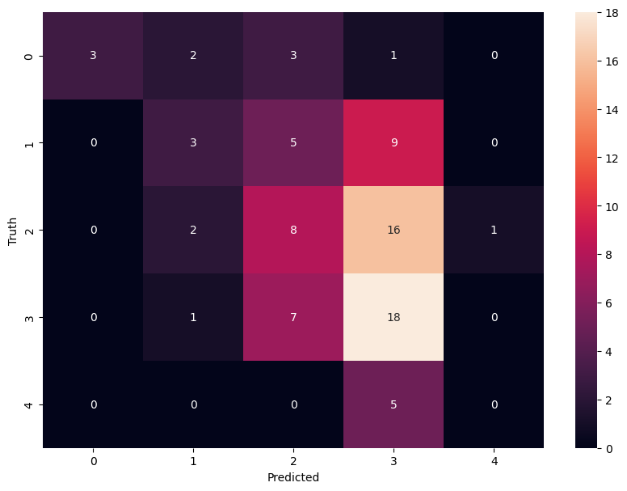

```python
#Confustion Matrix for test data
cm=confusion_matrix(y_test_arg,y_pred_test)
plt.figure(figsize=(10,7))
sns.heatmap(cm,annot=True,fmt='d')
plt.xlabel('Predicted')
plt.ylabel('Truth')
plt.show()
```

```python
#Predicting the model on train data
#We cant directy use one hot encoded data hence following below steps
y_train_arg=np.argmax(Y_train,axis=1)
y_pred_train = np.argmax(nn.predict(X_train_bow),axis=1)
```

```python
#Accuracy of train data
acc_train=accuracy_score(y_train_arg, y_pred_train)
print('Accuracy of train data:',acc_train)
```

```
Accuracy of train data: 0.907185628742515
```

```python
#Classification Report for train data
print(classification_report(y_train_arg, y_pred_train))
```

```
              precision    recall  f1-score   support

           0       1.00      0.97      0.99        36
           1       0.97      0.87      0.92        78
           2       0.87      0.86      0.87        79
           3       0.87      0.96      0.91       115
           4       0.92      0.88      0.90        25
           5       0.00      0.00      0.00         1

    accuracy                           0.91       334
   macro avg       0.77      0.76      0.76       334
weighted avg       0.91      0.91      0.91       334
```

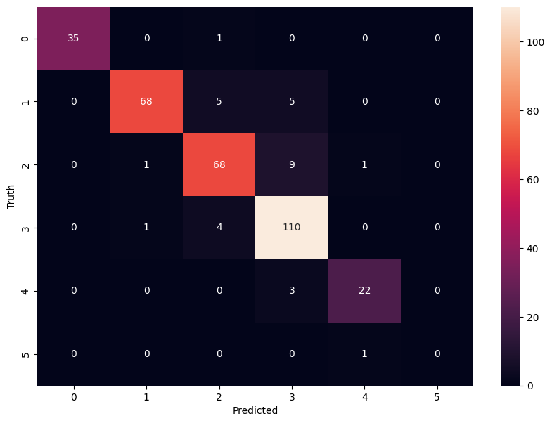

```python
#Confustion Matrix for train data
cm1=confusion_matrix(y_train_arg,y_pred_train)
plt.figure(figsize=(10,7))
sns.heatmap(cm1,annot=True,fmt='d')
plt.xlabel('Predicted')
plt.ylabel('Truth')
plt.show()
```

```python
#Loss and Accuracy curve
loss, accuracy  = nn.evaluate(X_test_bow.toarray(),Y_test, verbose=False)
```

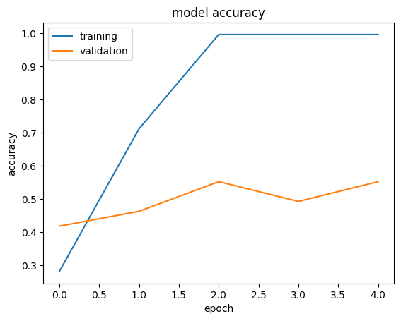

```python
#Accuracy curve
plt.plot(history.history['accuracy'])
plt.plot(history.history['val_accuracy'])
plt.title('model accuracy')
plt.ylabel('accuracy')
plt.xlabel('epoch')
plt.legend(['training', 'validation'], loc='best')
plt.show()
```

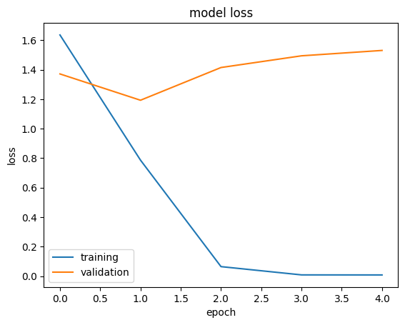

```python
#Loss curve
plt.plot(history.history['loss'])
plt.plot(history.history['val_loss'])
plt.title('model loss')
plt.ylabel('loss')
plt.xlabel('epoch')
plt.legend(['training', 'validation'], loc='best')
plt.show()
```

```python
#Add the accuracy results to results_df dataframe
results_df=results_concat(results_df,acc_test,acc_train,'NN')
```

**Summary on simple Neural Network results**:

Traning data seems to be Overfitting .

Performance matrix of Test data:

Accuracy : 0.38

Precision : 0.41

Recall : 0.38

F1-score: 0.35

Accuracy curve results:

Accuracy of training data drastically increased within few Epochs.

Loss curve results:

Loss of training data decreased within few Epochs.

Validation loss had reduced for initial few epochs but gradually increased.

We could clearly see overfitting in training data.

Validation data metrics are not too bad.

```python
#Tuning Neural Network
nn1 = Sequential()
#input layer
nn1.add(Dense(256,kernel_initializer='he_normal'))
#batch normalization
nn1.add(BatchNormalization())
#hidden layer
nn1.add(Activation('relu'))
#dropout
nn1.add(Dropout(0.2))
#hidden layer
nn1.add(Dense(256, kernel_initializer='he_normal'))
#batch normalization
nn1.add(BatchNormalization())
#hidden layer
nn1.add(Activation('relu'))
#dropout
nn1.add(Dropout(0.2))
#hidden layer
nn1.add(Dense(256, kernel_initializer='he_normal'))
#batch normalization
nn1.add(BatchNormalization())
#hidden layer
nn1.add(Activation('relu'))
#dropout
nn1.add(Dropout(0.2))
#hidden layer
nn1.add(Dense(6, kernel_initializer='he_normal',kernel_regularizer = regularizers.l2(0.0005650011028133052)))
#output layer
nn1.add(Activation('softmax'))
#optimizer
opt = optimizers.Adam(learning_rate =0.01714453879813377)
```

```python
#Compile the model
nn1.compile(optimizer = opt, loss = 'categorical_crossentropy', metrics = ['accuracy'])
```

```python
#Add parameters
batch_size = 15
epochs = 5
early_stopping = EarlyStopping(monitor='val_loss', mode='min', verbose=0, patience=3)
#Fit the model
history1=nn1.fit(X_train_bow.toarray(),Y_train, epochs = epochs, batch_size=batch_size, validation_split = 0.2,callbacks=[early_stopping])
```

```python
#Summary of the model
nn1.summary()
```

```
Model: "sequential_1"
_________________________________________________________________
 Layer (type)                Output Shape              Param #
=================================================================
 dense_5 (Dense)             (None, 256)               2992384

 batch_normalization (Batch  (None, 256)               1024
 Normalization)

 activation (Activation)     (None, 256)               0

 dropout (Dropout)           (None, 256)               0

 dense_6 (Dense)             (None, 256)               65792

 batch_normalization_1 (Bat  (None, 256)               1024
 chNormalization)

 activation_1 (Activation)   (None, 256)               0

 dropout_1 (Dropout)         (None, 256)               0

 dense_7 (Dense)             (None, 256)               65792

 batch_normalization_2 (Bat  (None, 256)               1024
 chNormalization)

 activation_2 (Activation)   (None, 256)               0

 dropout_2 (Dropout)         (None, 256)               0

 dense_8 (Dense)             (None, 6)                 1542

 activation_3 (Activation)   (None, 6)                 0

=================================================================
Total params: 3128582 (11.93 MB)
Trainable params: 3127046 (11.93 MB)
Non-trainable params: 1536 (6.00 KB)
_________________________________________________________________
```

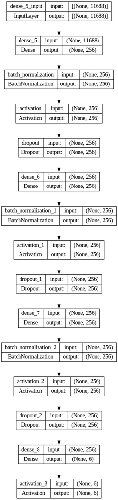

```python
#save model to file
plot_model(nn1, to_file='nn1_model.png', show_shapes=True, show_layer_names=True)
```

```python
# predicting the model on test data
#We cant directy use one hot encoded data hence following below steps
y_test_arg_1=np.argmax(Y_test,axis=1)
y_pred_test_1 = np.argmax(nn1.predict(X_test_bow),axis=1)
```

```python
#Accuracy of test data
acc_test_1=accuracy_score(y_test_arg_1, y_pred_test_1)
print('Accuracy:',acc_test_1)
```

```
Accuracy: 0.44047619047619047
```

```python
#Classification Report for test data
print(classification_report(y_test_arg_1, y_pred_test_1))
```

```
              precision    recall  f1-score   support

           0       0.75      0.33      0.46         9
           1       0.39      0.53      0.45        17
           2       0.44      0.44      0.44        27
           3       0.43      0.50      0.46        26
           4       0.00      0.00      0.00         5

    accuracy                           0.44        84
   macro avg       0.40      0.36      0.36        84
weighted avg       0.44      0.44      0.43        84
```

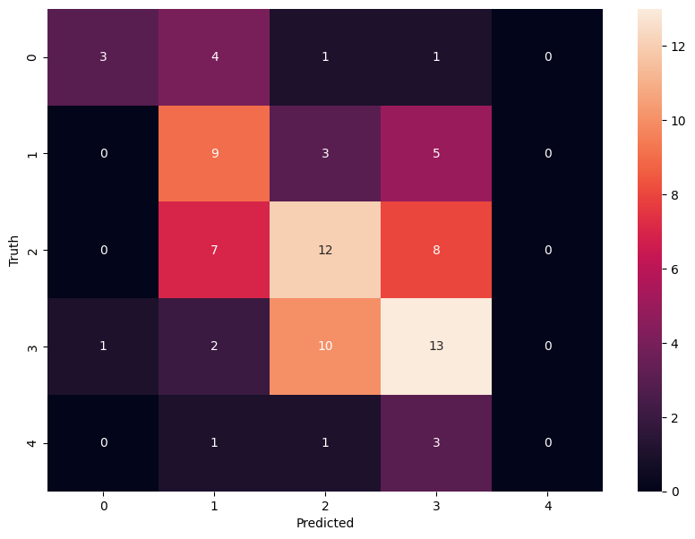

```python
#Confustion Matrix for test data
cm2=confusion_matrix(y_test_arg_1,y_pred_test_1)
plt.figure(figsize=(10,7))
sns.heatmap(cm2,annot=True,fmt='d')
plt.xlabel('Predicted')
plt.ylabel('Truth')
plt.show()
```

```python
#Predicting the model on train data
#We cant directy use one hot encoded data hence following below steps
y_train_arg_1=np.argmax(Y_train,axis=1)
y_pred_train_1 = np.argmax(nn1.predict(X_train_bow),axis=1)
```

```python
#Accuracy of train data
acc_train_1=accuracy_score(y_train_arg_1, y_pred_train_1)
print('Accuracy of train data:',acc_train_1)
```

```
Accuracy of train data: 0.8802395209580839
```

```python
#Classification Report for train data
print(classification_report(y_train_arg_1, y_pred_train_1))
```

```
              precision    recall  f1-score   support

           0       0.95      0.97      0.96        36
           1       0.87      0.91      0.89        78
           2       0.80      0.82      0.81        79
           3       0.91      0.89      0.90       115
           4       0.95      0.84      0.89        25
           5       0.00      0.00      0.00         1

    accuracy                           0.88       334
   macro avg       0.75      0.74      0.74       334
weighted avg       0.88      0.88      0.88       334
```

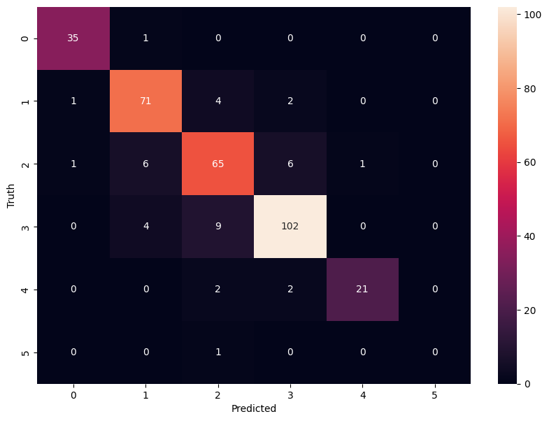

```python
#Confustion Matrix for train data
cm3=confusion_matrix(y_train_arg_1,y_pred_train_1)
plt.figure(figsize=(10,7))
sns.heatmap(cm3,annot=True,fmt='d')
plt.xlabel('Predicted')
plt.ylabel('Truth')
plt.show()
```

```python
#Loss and Accuracy curve
loss, accuracy  = nn1.evaluate(X_test_bow.toarray(),Y_test, verbose=False)
```

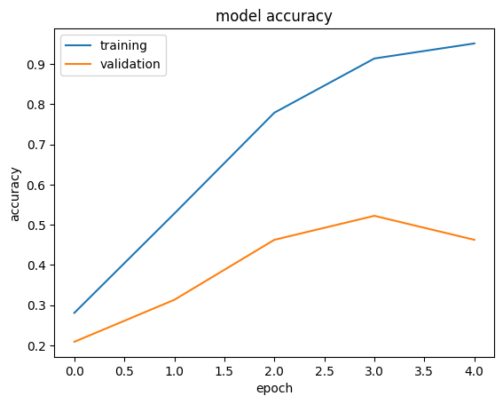

```python
#Accuracy curve
plt.plot(history1.history['accuracy'])
plt.plot(history1.history['val_accuracy'])
plt.title('model accuracy')
plt.ylabel('accuracy')
plt.xlabel('epoch')
plt.legend(['training', 'validation'], loc='best')
plt.show()
```

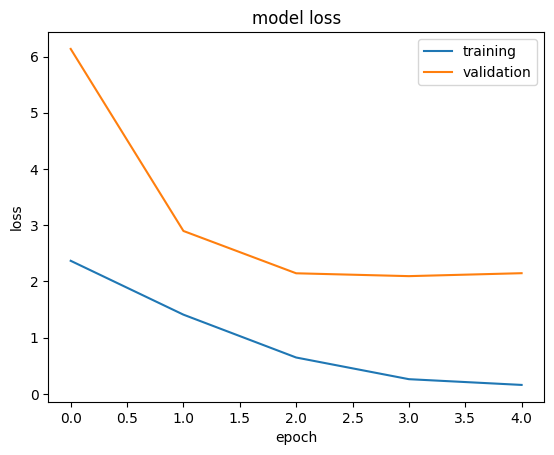

```python
#Loss curve
plt.plot(history1.history['loss'])
plt.plot(history1.history['val_loss'])
plt.title('model loss')
plt.ylabel('loss')
plt.xlabel('epoch')
plt.legend(['training', 'validation'], loc='best')
plt.show()
```

```python
#Add the accuracy results to results_df dataframe
results_df=results_concat(results_df,acc_test_1,acc_train_1,'NN Tuned')
```

**Summary on Tuned Neural Network results**:

Traning data seems to be Overfitting . But better than previous NN model.

Performance matrix of Test data:

Accuracy : 0.44

Precision : 0.44

Recall : 0.44

F1-score: 0.43

Loss curve results:

Training loss curve looks good. There was a gradual decrease in Loss.

# **Conclusion on Neural Networks**:

Overfitting in Training data was slighly reduced in Tuned model.

Accuracy of tuned model was better.

```python
#Save comparision result to csv for future use
results_df.to_csv('/content/drive/MyDrive/CAPSTONE_PROJECT/results_df.csv', index=False)
```

# **Step 2: Design, train and test RNN or LSTM classifiers**

```python
#Check type of train data
print("Type of x_train: ", type(X_train))
print("Type of y_train: ", type(y_train))
```

```
Type of x_train:  <class 'pandas.core.series.Series'>
Type of y_train:  <class 'numpy.ndarray'>
```

```python
#Check type of test data
print("Type of x_test: ", type(X_test))
print("Type of y_test: ", type(y_test))
```

```
Type of x_test:  <class 'pandas.core.series.Series'>
Type of y_test:  <class 'numpy.ndarray'>
```

```python
#Shape of data
print('x_train shape : ({0})'.format(X_train.shape[0]))
print('y_train shape : ({0},)'.format(y_train.shape[0]))
print('x_test shape : ({0})'.format(X_test.shape[0]))
print('y_test shape : ({0},)'.format(y_test.shape[0]))
```

```
x_train shape : (334)
y_train shape : (334,)
x_test shape : (84)
y_test shape : (84,)
```

```python
#Convert words into corresponding tokens
#Take frequent words as 5000
tokenizer = Tokenizer(num_words=5000)
tokenizer.fit_on_texts(X_train)
X_train = tokenizer.texts_to_sequences(X_train)
X_test = tokenizer.texts_to_sequences(X_test)
```

```python
#Pad the sequences using the max length
#vocabulary size
vocab_size = len(tokenizer.word_index) + 1
print("vocab_size:", vocab_size)
#Take max length as 100
maxlen = 100
#pad sequences
X_train = pad_sequences(X_train, padding='post', maxlen=maxlen)
X_test = pad_sequences(X_test, padding='post', maxlen=maxlen)
```

```
vocab_size: 2793
```

```python
print(X_train.shape,y_train.shape)
print(X_test.shape,y_test.shape)
```

```
(334, 100) (334,)
(84, 100) (84,)
```

```python
# Create a weight matrix using GloVe embeddings
project_path="/content/drive/MyDrive/Python Course/Project/NLP/"
from zipfile import ZipFile
# specifying the zip file name
file_name = project_path + "glove.6B.zip"
# opening the zip file in READ mode
with ZipFile(file_name, 'r') as zip:
    # printing all the contents of the zip file
    zip.printdir()
     # extracting all the files
    print('Extracting files...')
    zip.extractall()
    print('All the files extracted to local sesssion')
```

```
File Name                                             Modified             Size
glove.6B.50d.txt                               2014-08-04 13:15:00    171350079
glove.6B.100d.txt                              2014-08-04 13:14:34    347116733
glove.6B.200d.txt                              2014-08-04 13:14:44    693432828
glove.6B.300d.txt                              2014-08-27 12:19:16   1037962819
Extracting files...
All the files extracted to local sesssion
```

```python
#Take any one txt file. glove.6B.200d is the text file with 200 features. We will pick this file
glove6b_file = '/content/glove.6B.200d.txt'
glove6b_file
```

```
'/content/glove.6B.200d.txt'
```

```python
#We can update our dictionary with the new word and its corresponding vector.
embeddings_dict = {}
for line in open(glove6b_file):
    word = line.split(" ")[0]
    embeddings = line.split(" ")[1:]
    embeddings = np.asarray(embeddings, dtype = 'float32')
    embeddings_dict[word] = embeddings
```

```python
#Define parameters
#Max features sets the maximum number of features to be used to characterize texts in the training/classification process.
#This number affects how many computation resources are needed to train the model. More features means more computation time is necessary.
#We will define max_features as 10000
max_features = 10000
#maximum length of all sequences. If not provided, by default it will use the maximum length of the longest sentence
#We will define max length as 100
maxlen = 100
#Embed_size is the size of Embedding word vectors
#The embeddings can be of any number of dimensions. Word2Vec guidance is vague on this and suggests between 100 and 1000.
#Typically more dimensions = greater quality encoding, but there will be some limit beyond which you'll get diminishing returns.
#We typically use 200 or 300.
#Here we will define embedding size as 200
embed_size = 200
```

```python
#Create the weight matrix
embedding_matrix = np.zeros((vocab_size, 200))
for word, i in tokenizer.word_index.items():
    embedding_vector = embeddings_dict.get(word)
    if embedding_vector is not None:
        embedding_matrix[i] = embedding_vector
```

```python
#Check the weight matrix
embedding_matrix
```

```
array([[ 0.        ,  0.        ,  0.        , ...,  0.        ,
         0.        ,  0.        ],
       [ 0.12782   ,  0.28417   , -0.045819  , ...,  0.12043   ,
        -0.57577002,  0.28336999],
       [ 0.43524   , -0.75510001,  0.26128   , ...,  0.11221   ,
         0.040631  , -0.28641   ],
       ...,
       [ 0.95943999, -0.010548  ,  0.071963  , ...,  0.028982  ,
        -0.74164999, -0.021697  ],
       [-0.033869  , -0.19428   , -0.18445   , ...,  0.39454001,
        -0.20663001, -0.051778  ],
       [ 0.21935   ,  0.84495997,  0.18075   , ...,  0.81076002,
         0.074568  ,  0.71315998]])
```

```python
#Define and compile simple LSTM model
#Input layer. Shape will be max length
input_layer = Input(shape=(maxlen,))
#Embedding layer
embedding=Embedding(vocab_size, embed_size, weights=[embedding_matrix], trainable=False)(input_layer)
#embedding = Embedding(embedding_matrix.shape[0],output_dim=200,weights=[embedding_matrix],input_length=maxlen, trainable=True)(input_layer)
#LSTM
lstm=Bidirectional(LSTM(128))(embedding)
#Dropout
dropout=Dropout(0.3)(lstm)
#Dense
dense =Dense(100,activation='relu')(dropout)
#Output layer. Use softmax activation
output=Dense(6,activation='softmax')(dense)
```

```python
lstm_model = Model(input_layer,output)
#Compile model. Use adam optimizer
lstm_model.compile(loss='categorical_crossentropy',optimizer="adam",metrics=['accuracy'])
#display summary
lstm_model.summary()
```

```
Model: "model"
_________________________________________________________________
 Layer (type)                Output Shape              Param #
=================================================================
 input_1 (InputLayer)        [(None, 100)]             0

 embedding (Embedding)       (None, 100, 200)          558600

 bidirectional (Bidirection  (None, 256)               336896
 al)

 dropout_3 (Dropout)         (None, 256)               0

 dense_9 (Dense)             (None, 100)               25700

 dense_10 (Dense)            (None, 6)                 606

=================================================================
Total params: 921802 (3.52 MB)
Trainable params: 363202 (1.39 MB)
Non-trainable params: 558600 (2.13 MB)
_________________________________________________________________
```

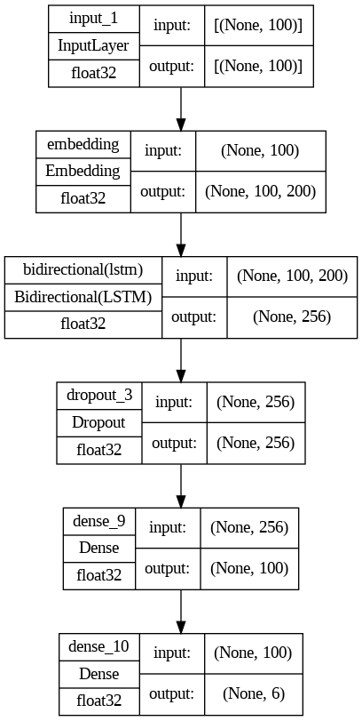

```python
#Save model to file
plot_model(lstm_model, to_file='model_plot1.png', show_shapes=True, show_dtype=True, show_layer_names=True)
```

```python
#Set parameters
#Take only 10 epochs
lr_reducton = ReduceLROnPlateau(monitor='val_accuracy', patience = 2, verbose=1,factor=0.5, min_lr=0.00001)
batch_size=256
epochs=10
```

```python
y_train.shape
```

```
(334,)
```

```python
# Convert both the training and test labels into one-hot encoded vectors:
y_train_1 = to_categorical(y_train_new)
y_test_1 =  to_categorical(y_test_new)
```

```python
y_train_1.shape
```

```
(334, 6, 2)
```

```python
y_test_1.shape
```

```
(84, 6, 2)
```

```python
X_train.shape
```

```
(334, 100)
```

```python
#Fit the model
lstm_model1 = lstm_model.fit(X_train,y_train_new,batch_size=batch_size, validation_data=(X_test, y_test_new), epochs=epochs, verbose=1,callbacks=lr_reducton)
```

```
Epoch 3: ReduceLROnPlateau reducing learning rate to 0.0005000000237487257.
Epoch 5: ReduceLROnPlateau reducing learning rate to 0.0002500000118743628.
Epoch 7: ReduceLROnPlateau reducing learning rate to 0.0001250000059371814.
Epoch 9: ReduceLROnPlateau reducing learning rate to 6.25000029685907e-05.
```

```python
# list all data
print(lstm_model1.history.keys())
```

```
dict_keys(['loss', 'accuracy', 'val_loss', 'val_accuracy', 'lr'])
```